# Wybór najlepszego modelu do predykcji zmiennych dotyczących transakcji bankowych

Kasper Kurzyński

13.02.2022

[figure not shown]

## **Wstęp**

Zbiór zawiera następujące zmienne:

- **id** - id transakcji
- **initialtransaction_id** - id transakcji inicjalizującej
- **createtime** - data i czas utworzenia transakcji
- **amount** - kwota przelewu
- **browseragent** - przeglądarka klienta
- **description** - tytuł płatności
- **recurringaction** - informacja o rodzaju płatności rekurencyjnej
- **screenheight** - wysokość ekranu urządzenia klienta
- **screenwidth** - szerokość ekranu urządzenia klienta
- **acquirerconnectionmethod** - sposób łączenia się (zmienna techniczna)
- **expirymonth** - miesiąc wygaśnięcia karty
- **expiryyear** - rok wygaśnięcia karty
- **issuer** - wystawca karty
- **type** - rodzaj karty
- **level** - klasa karty
- **countrycode** - kraj wydania karty
- **listtype** - sektor działania partnera
- **mccname** - nazwa branży w jakiej działa partner
- **payclickedtime** - data i czas potwierdzenia transakcji przez klienta po uzupełnieniu danych kartowych
- **status** - status płatności

Celem projektu jest zbudowanie oraz wskazanie najlepszego modelu predykcyjnego dla zmiennej jakościowej wskazującej czy transakcja rekurencyjna jest udana - **status**, a także zbudowanie oraz wskazanie najlepszego modelu predykcyjnego dla zmiennej ilościowej **amount**.

## **Wczytanie danych oraz odpowiednich bibliotek potrzebnych do zrealizowania projektu**

Do realizacji projektu zostały wykorzystane poniższe biblioteki. Między innymi użyto takich pakietów jak “dplyr”, “randomForest” lub “rpart”.

```r
setwd("C:/Users/Kasper/OneDrive/Pulpit/Applied Statistics/mn_workshop")
load("dane_zaliczenie.RData")
library(dplyr)
library(ggplot2)
library(gridExtra)
library(tree)
library(earth)
library(rpart)
library(rpart.plot)
library(adabag)
library(randomForestSRC)
library(randomForest)
library(caTools)
library(pander)
library(wrapr)
library(adabag)
library(Hmisc)
library(tidyverse)
library(caret)
library(leaps)
library(kableExtra)
library(extrafont)
panderOptions("plain.ascii", TRUE)
panderOptions("keep.trailing.zeros", TRUE)
panderOptions("table.style", "simple")
perf_justify <- "lrrr"
```

## **Przygotowanie danych do zadania 1.**

### Utworzenie próby walidacyjnej

Próba walidacyjna została utworzona w celu dokonania oceny szacowanych modeli, ponieważ w pierwotnej próbie testowej zmienne zależne nie występowały.

```r
set.seed(100)
n <- nrow(proba_uczaca)
liczby_dzielace <- sample(c(1:n), round(0.75*n), replace = FALSE)

nowa_uczaca <- proba_uczaca[liczby_dzielace,]
proba_walidacyjna <- proba_uczaca[-liczby_dzielace,]
```

### Eksploracja danych - próba ucząca

Obiektem badania są transakcje rekurencyjne (transakcje dotyczące zarejestrowanej karty). Posiadają one warianty: AUTO lub MANUAL, w zbiorze danych “proba_uczaca” występuje tylko wariant pierwszy, dlatego ze zbioru danych “proba_testowa” wariant drugi (3 obserwacje) został wykluczony.

Większość zmiennych w zbiorze zaklasyfikowana jest jako “character” - poniżej zostały one przekonwertowane na zmienne jakościowe (“factor”). Występuje tylko jedna zmienna ilościowa wyrażona na skali ilorazowej - **amount**. Co więcej, warianty zmiennej **description**: “” oraz “NA” zostały ujednolicone i zastąpione wariantem “Brak opisu”. Tak jak wspomniano wyżej, obiektem badania są transakcje rekurencyjne, dlatego usunięto wszystkie warianty zmiennej **recurringaction** z wyjątkiem “AUTO” (wariant “MANUAL” nie występuje w zbiorze “proba_uczaca”).

Tak jak wspomniano wyżej, obiektem badania są transakcje rekurencyjne, dlatego usunięto wszystkie warianty zmiennej **recurringaction** z wyjątkiem “AUTO” (wariant “MANUAL” nie występuje w zbiorze “proba_uczaca”). Po nałożeniu filtra na transakcje rekurencyjne zmienna **recurringaction** została usunięta ze zbioru danych.

Zmienna **status** została zredukowana do dwóch wariantów: “success” (pierwotnie “completed successfully”), oraz “fail” (na którą składają się warianty: “card limit exceeded” “bank declined”, “do not honor”, oraz “NA”). Dodatkowo uwzględniono zmienną określającą dzień tygodnia, w którym miała miejsce transakcja - **weekDay**, która została stworzona na podstawie zmiennej **createtime**.

```r
head(nowa_uczaca)
```

```
##            id initialtransaction_id          createtime amount browseragent
## 125752 143588                 73468 2021-06-08 07:24:53  50.00         <NA>
## 111490  49711                 49534 2020-11-08 00:20:21  25.00         <NA>
## 27795   39929                  1056 2020-10-14 23:14:10  25.00         <NA>
## 29146   23244                  1102 2020-09-04 12:58:17  30.00         <NA>
## 126698  96723                 75934 2021-03-07 11:01:18  15.00         <NA>
## 146289 133965                118176 2021-05-21 22:00:42   9.99         <NA>
##            description recurringaction screenheight screenwidth
## 125752                            AUTO         <NA>        <NA>
## 111490 Orange On-line:            AUTO         <NA>        <NA>
## 27795  Orange On-line:            AUTO         <NA>        <NA>
## 29146  Orange On-line:            AUTO         <NA>        <NA>
## 126698    Orange Flex:            AUTO         <NA>        <NA>
## 146289  Bez ograniczen            AUTO         <NA>        <NA>
##        acquirerconnectionmethod expirymonth expiryyear     issuer   type
```

[output cut: 27 more lines]

```r
tail(nowa_uczaca)
```

```
##            id initialtransaction_id          createtime amount
## 1011    13603                    38 2020-08-10 06:11:32  30.00
## 147729 161667                126139 2021-07-06 17:00:26  10.00
## 11231  121870                   395 2021-04-29 08:01:34 142.45
## 50127    5804                  1781 2020-07-18 15:11:19  15.00
## 142858 148396                105281 2021-06-15 20:41:35  12.00
## 152934    468                    NA 2020-02-09 20:03:03  44.04
##                                                                                                               browseragent
## 1011                                                                                                                  <NA>
## 147729                                                                                                                <NA>
## 11231                                                                                                                 <NA>
## 50127                                                                                                                 <NA>
## 142858                                                                                                                <NA>
## 152934 Mozilla/5.0 (Windows NT 10.0; Win64; x64) AppleWebKit/537.36 (KHTML, like Gecko) Chrome/79.0.3945.130 Safari/537.36
##            description   recurringaction screenheight screenwidth
```

[output cut: 34 more lines]

```r
str(nowa_uczaca)
```

```
## 'data.frame':    22059 obs. of  20 variables:
##  $ id                      : int  143588 49711 39929 23244 96723 133965 12395 74363 9777 156891 ...
##  $ initialtransaction_id   : int  73468 49534 1056 1102 75934 118176 987 13933 2269 137856 ...
##  $ createtime              : POSIXct, format: "2021-06-08 07:24:53" "2020-11-08 00:20:21" ...
##  $ amount                  : num  50 25 25 30 15 9.99 90 25 50 9.99 ...
##  $ browseragent            : chr  NA NA NA NA ...
##  $ description             : chr  "" "Orange On-line:" "Orange On-line:" "Orange On-line:" ...
##  $ recurringaction         : chr  "AUTO" "AUTO" "AUTO" "AUTO" ...
##  $ screenheight            : chr  NA NA NA NA ...
##  $ screenwidth             : chr  NA NA NA NA ...
##  $ acquirerconnectionmethod: chr  "FDP_SOAP" "FDP_SOAP" "FDP_SOAP" "FDP_SOAP" ...
##  $ expirymonth             : int  3 9 9 2 9 3 3 10 8 3 ...
##  $ expiryyear              : int  2023 2021 2022 2024 2023 2025 2024 2021 2022 2025 ...
##  $ issuer                  : chr  "MASTERCARD" "VISA" "VISA" "MASTERCARD" ...
##  $ type                    : chr  "CREDIT" "CREDIT" "DEBIT" "DEBIT" ...
##  $ level                   : chr  "STANDARD" "PLATINUM" "ELECTRON" "STANDARD" ...
##  $ countrycode             : chr  "PL" "PL" "PL" "PL" ...
##  $ listtype                : chr  "ECOMMERCE" "ECOMMERCE" "ECOMMERCE" "ECOMMERCE" ...
##  $ mccname                 : chr  "Sieci komputerowe usługi informacyjne" "Usługi biznesowe gdzie indziej nie sklasyfikowane" "Usługi biznesowe gdzie indziej nie sklasyfikowane" "Usługi biznesowe gdzie indziej nie sklasyfikowane" ...
##  $ payclickedtime          : POSIXct, format: NA NA ...
##  $ status                  : Factor w/ 4 levels "bank declined",..: 4 4 2 2 4 3 4 4 4 2 ...
```

```r
summary(nowa_uczaca)
```

```
##        id         initialtransaction_id   createtime
##  Min.   :    17   Min.   :    17        Min.   :2020-01-09 00:07:19
##  1st Qu.: 43698   1st Qu.:  1689        1st Qu.:2020-10-24 01:30:07
##  Median : 81897   Median : 26387        Median :2021-01-30 15:15:10
##  Mean   : 81464   Mean   : 37696        Mean   :2021-01-19 02:40:50
##  3rd Qu.:121343   3rd Qu.: 64408        3rd Qu.:2021-04-28 07:26:20
##  Max.   :162463   Max.   :162231        Max.   :2021-07-07 23:51:06
##                   NA's   :3028
##      amount        browseragent       description        recurringaction
##  Min.   :   0.96   Length:22059       Length:22059       Length:22059
##  1st Qu.:  15.00   Class :character   Class :character   Class :character
##  Median :  30.00   Mode  :character   Mode  :character   Mode  :character
##  Mean   :  60.02
##  3rd Qu.:  50.00
##  Max.   :3450.58
##
##  screenheight       screenwidth        acquirerconnectionmethod  expirymonth
##  Length:22059       Length:22059       Length:22059             Min.   : 1.00
##  Class :character   Class :character   Class :character         1st Qu.: 3.00
##  Mode  :character   Mode  :character   Mode  :character         Median : 7.00
##                                                                 Mean   : 6.51
##                                                                 3rd Qu.: 9.00
##                                                                 Max.   :12.00
##
##    expiryyear      issuer              type              level
##  Min.   :2020   Length:22059       Length:22059       Length:22059
##  1st Qu.:2022   Class :character   Class :character   Class :character
##  Median :2023   Mode  :character   Mode  :character   Mode  :character
##  Mean   :2023
##  3rd Qu.:2024
##  Max.   :2029
##
##  countrycode          listtype           mccname
##  Length:22059       Length:22059       Length:22059
##  Class :character   Class :character   Class :character
##  Mode  :character   Mode  :character   Mode  :character
##
##
##
##
##  payclickedtime                                   status
##  Min.   :2020-01-09 00:09:12   bank declined         :   33
##  1st Qu.:2020-07-15 15:37:34   card limit exceeded   : 3485
##  Median :2020-11-12 18:14:05   do not honor          :  303
##  Mean   :2020-11-07 06:12:59   completed successfully:15210
##  3rd Qu.:2021-03-06 23:25:55   NA's                  : 3028
##  Max.   :2021-07-07 15:34:35
##  NA's   :19031
```

### Transformacja danych

Poniżej przedstawiono szereg operacji mający na celu przygotowanie próby uczącej do dalszych analiz.

```r
nowa_uczaca$description <- ifelse(nowa_uczaca$description == "", "Brak opisu", nowa_uczaca$description)
nowa_uczaca$description <- ifelse(is.na(nowa_uczaca$description), "Brak opisu", nowa_uczaca$description)

nowa_uczaca <- nowa_uczaca %>%
  select(id, createtime, amount, description, recurringaction, acquirerconnectionmethod, expirymonth, expiryyear, issuer,
         type, level, countrycode, listtype, mccname, status) %>%
  filter(recurringaction == "AUTO") %>%
  mutate(acquirerconnectionmethod = factor(acquirerconnectionmethod),
         expirymonth = factor(expirymonth),
         description = factor(description),
         expiryyear = factor(expiryyear),
         issuer = factor(issuer),
         type = factor(type),
         level = factor(level),
         countrycode = factor(countrycode),
         listtype = factor(listtype),
         mccname = factor(mccname))

nowa_uczaca$recurringaction <- NULL

nowa_uczaca$weekDay <- weekdays(as.Date(nowa_uczaca$createtime))
nowa_uczaca$weekDay <- as.factor(nowa_uczaca$weekDay)
nowa_uczaca$status <- ifelse(nowa_uczaca$status == "completed successfully", "success", "fail")
nowa_uczaca$status <- as.factor(nowa_uczaca$status)

nowa_uczaca$weekDay <- factor(nowa_uczaca$weekDay, levels= c("poniedziałek", "wtorek",
                                         "środa", "czwartek", "piątek", "sobota", "niedziela"))
```

### Podsumowanie zmian

Skutkiem transformacji było między innymi zamienienie typu zmiennych na **factor**.

```r
str(nowa_uczaca)
```

```
## 'data.frame':    19031 obs. of  15 variables:
##  $ id                      : int  143588 49711 39929 23244 96723 133965 12395 74363 9777 156891 ...
##  $ createtime              : POSIXct, format: "2021-06-08 07:24:53" "2020-11-08 00:20:21" ...
##  $ amount                  : num  50 25 25 30 15 9.99 90 25 50 9.99 ...
##  $ description             : Factor w/ 11 levels " platnosci za faktury za tv internet telefon",..: 3 6 6 6 5 2 7 5 3 10 ...
##  $ acquirerconnectionmethod: Factor w/ 2 levels "ECARD_REST","FDP_SOAP": 2 2 2 2 2 1 2 2 2 1 ...
##  $ expirymonth             : Factor w/ 12 levels "1","2","3","4",..: 3 9 9 2 9 3 3 10 8 3 ...
##  $ expiryyear              : Factor w/ 10 levels "2020","2021",..: 4 2 3 5 4 6 5 2 3 6 ...
##  $ issuer                  : Factor w/ 3 levels "MAESTRO","MASTERCARD",..: 2 3 3 2 2 2 2 3 3 3 ...
##  $ type                    : Factor w/ 2 levels "CREDIT","DEBIT": 1 1 2 2 2 2 1 2 2 2 ...
##  $ level                   : Factor w/ 31 levels "BLACK","BUSINESS",..: 23 17 7 23 23 23 23 3 3 3 ...
##  $ countrycode             : Factor w/ 32 levels "AE","AZ","BY",..: 25 25 25 25 25 25 25 25 25 25 ...
##  $ listtype                : Factor w/ 3 levels "ECOMMERCE","MWF",..: 1 1 1 1 1 1 2 1 1 1 ...
##  $ mccname                 : Factor w/ 6 levels "NULL","Restauracja",..: 3 6 6 6 6 1 6 6 3 1 ...
##  $ status                  : Factor w/ 2 levels "fail","success": 2 2 1 1 2 1 2 2 2 1 ...
##  $ weekDay                 : Factor w/ 7 levels "poniedziałek",..: 2 6 3 5 7 5 5 7 5 2 ...
```

```r
summary(nowa_uczaca)
```

```
##        id           createtime                      amount
##  Min.   :  2441   Min.   :2020-07-08 00:30:31   Min.   :   0.96
##  1st Qu.: 48517   1st Qu.:2020-11-04 20:55:39   1st Qu.:  25.00
##  Median : 86618   Median :2021-02-11 15:56:39   Median :  30.00
##  Mean   : 85436   Mean   :2021-01-30 16:52:48   Mean   :  63.92
##  3rd Qu.:123798   3rd Qu.:2021-05-03 08:18:17   3rd Qu.:  50.00
##  Max.   :162463   Max.   :2021-07-07 23:51:06   Max.   :2712.64
##
##                    description   acquirerconnectionmethod  expirymonth
##  Brak opisu              :6852   ECARD_REST: 1391         2      :1828
##  Orange Flex:            :6267   FDP_SOAP  :17640         9      :1827
##  Orange On-line:         :2698                            8      :1820
##  PLAY - FAKTURA          :1891                            10     :1713
##  Przejazd A4Go           :1046                            1      :1567
##  RedBull Mobile - FAKTURA:  92                            5      :1566
##  (Other)                 : 185                            (Other):8710
##    expiryyear          issuer          type            level
##  2024   :4917   MAESTRO   :   16   CREDIT: 2664   CLASSIC :6899
##  2023   :4814   MASTERCARD: 8737   DEBIT :16367   STANDARD:6585
##  2022   :3817   VISA      :10278                  GOLD    :1838
##  2025   :2472                                     BUSINESS:1674
##  2021   :2429                                     ELECTRON: 684
##  2026   : 290                                     WORLD   : 414
##  (Other): 292                                     (Other) : 937
##   countrycode         listtype
##  PL     :17309   ECOMMERCE:15584
##  GB     :  892   MWF      : 3207
##  UA     :  268   PUBLIC   :  240
##  BY     :  110
##  US     :  105
##  TR     :   62
##  (Other):  285
##                                               mccname          status
##  NULL                                             :  527   fail   : 3821
##  Restauracja                                      :   16   success:15210
##  Sieci komputerowe usługi informacyjne            : 4386
##  Sklepy spożywcze różne                           :   58
##  Ubezpieczenia                                    :  426
##  Usługi biznesowe gdzie indziej nie sklasyfikowane:13618
##
##          weekDay
##  poniedziałek:3386
##  wtorek      :3214
##  środa       :2784
##  czwartek    :2674
##  piątek      :2781
##  sobota      :2090
##  niedziela   :2102
```

### Wizualizacja danych na podstawie nowej próby uczącej

W przypadku zmiennej zależnej **success** liczba transakcji udanych jest znacząco większa niż liczba transakcji nieudanych - stanowi ona 80% wszystkich uwzględnionych w badaniu obserwacji.

Podobne dysproporcje obserwuje się w przypadku zmiennej **type** - 2664 obserwacje dotyczą transakcji z wykorzystaniem kart kredytowych, a aż 16367 obserwacji to transakcje z wykorzystaniem kart debetowych. Rozkład zmiennej **expiryyear** jest najbardziej zbliżony do rozkładu normalnego (jeśliby wykluczyć obserwacje nietypowe tj. utratę ważności karty w latach 2027-2029, która występuje tylko w przypadku 0,26% wszystkich obserwacji). Jeśli chodzi o zmienną **weekDay**, najwięcej transakcji dokonywanych jest w poniedziałek i w miarę upływu tygodnia ich liczba stopniowo się zmniejsza (z wyjątkiem piątku, dla którego wartość zmiennej nieco wzrasta).

W przypadku zmiennej **mccname** znaczna większość obserwacji dotyczy “usług biznesowych nigdzie indziej niesklasyfikowanych”. Spośród sklasyfikowanych usług największą licznę obserwacji stanowią “sieci komputerowe, usługi informacyjne”. Pozostałe warianty zmiennej mają znacząco mniejsze liczebności. Wystawcą karty (zmienna **issuer**) najczęściej jest “VISA” (10278 obserwacji), choć wariant “MASTERCARD” jest niewiele mniej liczny (8737 obserwacji), zaś transakcje z użyciem karty “MAESTRO” to tylko 16 obserwacji i mogą one zostać wykluczone. W przypadku 15584 obserwacji sektor działania partnera biznesowego (zmienna **listtype**) to “ECOMMERCE”, pozostałe znacznie mniej liczne warianty to “MFW” oraz “PUBLIC”.

Histogramy dla każdej z uwzględnionych na wykresach zmiennych (**amount**, **amount** x **fail**, **amount** x **success**, **amount** x **CREDIT**, **amount** x **DEBIT**, **amount** x **ECOMMERCE**, **amount** x **MWF**, **amount** x **MASTERCARD**, **amount** x **VISA**) wskazują na wysoką asymetrię prawostronną, co może wskazywać na występowanie jednostek odstających o wysokich wartościach.

```r
plotStat <- nowa_uczaca %>%
  count(status) %>%
  ggplot() + geom_col(aes(x = status, y = n, fill = status), alpha = 0.8) +
  geom_label(aes(x = status, y = n, label = n)) +
  scale_fill_manual(values = c("tomato3","royalblue2")) +
  theme_minimal() +
  ggtitle('Liczba nieudanych i udanych transakcji') +
  theme(axis.title.y = element_text(color="Grey23", size=16),
        axis.text.y = element_text(size=10),
        axis.title.x=element_blank(),
        legend.title = element_text(size=12),
        legend.text = element_text(size=8),
        legend.position = "right",
        legend.justification = c(0.94,0.94),
        legend.background = element_rect(fill="gray90",
                                         size=0.5, linetype="solid",
                                         colour ="gray10"),
        plot.title = element_text(color="gray10", size=22, family="serif"))


#Type
plotType <- nowa_uczaca %>%
  count(type) %>%
  ggplot() + geom_col(aes(x = type, y = n, fill = type), alpha = 0.8) +
  geom_label(aes(x = type, y = n, label = n)) +
  scale_fill_manual(values = c("deepskyblue2","darkorange2")) +
  theme_minimal() +
  ggtitle('Liczba transakcji w zależności od typu karty') +
  theme(axis.title.y = element_text(color="Grey23", size=16),
        axis.text.y = element_text(size=10),
        axis.title.x=element_blank(),
        legend.position = "none",
        plot.title = element_text(color="gray10", size=22, family="serif"))

#Expiryyear
plotExpy <- nowa_uczaca %>%
  count(expiryyear) %>%
  ggplot() + geom_col(aes(x = expiryyear, y = n, fill = expiryyear), alpha = 0.8) +
  geom_label(aes(x = expiryyear, y = n, label = n)) +
  scale_fill_manual(values = c("violetred4","seagreen4", "goldenrod4", "lightskyblue4", "sienna4",
                               "violetred2","seagreen2", "goldenrod2", "lightskyblue2", "sienna2")) +
  theme_minimal() +
  ggtitle("Rok utraty ważności karty") +
  theme(axis.title.y = element_text(color="Grey23", size=16),
        axis.text.y = element_text(size=10),
        axis.title.x=element_blank(),
        legend.position = "none",
        plot.title = element_text(color="gray10", size=22, family="serif"))

#weekDay
plotWeekd <- nowa_uczaca %>%
  count(weekDay) %>%
  ggplot() + geom_col(aes(x = weekDay, y = n, fill = weekDay), alpha = 0.8) +
  geom_label(aes(x = weekDay, y = n, label = n)) +
  scale_fill_manual(values = c("gray86","firebrick3", "darkseagreen4", "yellow2", "pink3",
                               "mediumpurple4","orange3")) +
  theme_minimal() +
  ggtitle("Dzień dokonania transakcji") +
  theme(axis.title.y = element_text(color="Grey23", size=16),
        axis.text.y = element_text(size=10),
        axis.title.x=element_blank(),
        legend.position = "none",
        plot.title = element_text(color="gray10", size=22, family="serif"))


#mccname
plotMccname <- nowa_uczaca %>%
  count(mccname) %>%
  ggplot() + geom_col(aes(x = mccname, y = n, fill = mccname), alpha = 0.7) +
  geom_label(aes(x = mccname, y = n, label = n)) +
  scale_fill_manual(values = c("deeppink3", "gray50", "blue3", "gray50", "gray50", "green4", "red2")) +
  theme_minimal() +
  ggtitle("Liczba transakcji w zależności od zmiennej Mccname") +
  theme(axis.title.y = element_text(color="Grey23", size=16),
        axis.text.y = element_text(size=10),
        axis.title.x = element_blank(),
        axis.text.x = element_blank(),
        legend.title = element_text(size=8),
        legend.text = element_text(size=6),
        legend.position = "right",
        legend.justification = c(0.8,0.8),
        legend.background = element_rect(fill="gray90",
                                         size=0.5, linetype="solid",
                                         colour ="gray10"),
        plot.title = element_text(color="gray10", size=19, family="serif"))

#issuer
plotIssuer <- nowa_uczaca %>%
  count(issuer) %>%
  ggplot() + geom_col(aes(x = issuer, y = n, fill = issuer), alpha = 0.7) +
  geom_label(aes(x = issuer, y = n, label = n)) +
  scale_fill_manual(values = c("dodgerblue2", "chocolate2", "slateblue3")) +
  theme_minimal() +
  ggtitle("Liczba transakcji w zależności od zmiennej Issuer") +
  theme(axis.title.y = element_text(color="Grey23", size=16),
        axis.text.y = element_text(size=10),
        axis.title.x = element_blank(),
        legend.position = "none",
        plot.title = element_text(color="gray10", size=19, family="serif"))

#listtype
plotListt <- nowa_uczaca %>%
  count(listtype) %>%
  ggplot() + geom_col(aes(x = listtype, y = n, fill = listtype), alpha = 0.7) +
  geom_label(aes(x = listtype, y = n, label = n)) +
  scale_fill_manual(values = c("seagreen3", "gold3", "indianred3")) +
  theme_minimal() +
  ggtitle("Listtype") +
  theme(axis.title.y = element_text(color="Grey23", size=16),
        axis.text.y = element_text(size=10),
        axis.title.x = element_blank(),
        legend.position = "none",
        plot.title = element_text(color="gray10", size=19, family="serif"))


#Histogram dla zmiennej amount
plotAmount <- ggplot(nowa_uczaca, aes(x = amount)) + geom_histogram(binwidth = 200, alpha = 0.7, fill = "darkorange3") + theme_minimal() +
  ggtitle('Rozkład zmiennej amount') +
  theme(axis.title.y = element_text(color="Grey23", size=11),
        axis.text.y = element_text(size=9),
        axis.title.x = element_text(color="Grey23", size=11),
        axis.text.x = element_text(size=9),
        plot.title = element_text(color="gray10", size=19, family="serif"))

#Histogram dla zmiennej amount + status
plotAmStat <- ggplot(nowa_uczaca, aes(x = amount, fill=status)) + geom_histogram(binwidth = 200, alpha = 0.7) + facet_grid(~status) + theme_minimal() +
  scale_fill_manual(values = c("tomato3","royalblue2")) +
  ggtitle('Rozkład zmiennej amount z podziałem na status transakcji') +
  theme(axis.title.y = element_text(color="Grey23", size=11),
        axis.text.y = element_text(size=9),
        axis.title.x = element_text(color="Grey23", size=11),
        axis.text.x = element_text(size=9),
        legend.position = "none",
        plot.title = element_text(color="gray10", size=19, family="serif"))

#Histogram dla zmiennej amount + type
plotAmTyp <- ggplot(nowa_uczaca, aes(x = amount, fill=type)) + geom_histogram(binwidth = 200, alpha = 0.7) + facet_grid(~type) + theme_minimal() +
  scale_fill_manual(values = c("deepskyblue2","darkorange2")) +
  ggtitle('Rozkład zmiennej amount z podziałem na typ karty') +
  theme(axis.title.y = element_text(color="Grey23", size=11),
        axis.text.y = element_text(size=9),
        axis.title.x = element_text(color="Grey23", size=11),
        axis.text.x = element_text(size=9),
        legend.position = "none",
        plot.title = element_text(color="gray10", size=19, family="serif"))

#Histogram dla zmiennej amount + listtype

doHist <- nowa_uczaca[nowa_uczaca$listtype != "PUBLIC" & nowa_uczaca$issuer != "MAESTRO",]

plotAmListt <- ggplot(doHist, aes(x = amount, fill=listtype)) + geom_histogram(binwidth = 200, alpha = 0.7) + facet_grid(~listtype) + theme_minimal() +
  scale_fill_manual(values = c("seagreen3", "gold3")) +
  ggtitle('Rozkład zmiennej amount z podziałem sektor działania partnera') +
  theme(axis.title.y = element_text(color="Grey23", size=11),
        axis.text.y = element_text(size=9),
        axis.title.x = element_text(color="Grey23", size=11),
        axis.text.x = element_text(size=9),
        legend.position = "none",
        plot.title = element_text(color="gray10", size=19, family="serif"))

#Histogram dla zmiennej amount + issuer
plotAmIss <- ggplot(doHist, aes(x = amount, fill=issuer)) + geom_histogram(binwidth = 200, alpha = 0.7) + facet_grid(~issuer) + theme_minimal() +
  scale_fill_manual(values = c("chocolate2", "slateblue3")) +
  ggtitle('Rozkład zmiennej amount z podziałem na wystawcę karty') +
  theme(axis.title.y = element_text(color="Grey23", size=11),
        axis.text.y = element_text(size=9),
        axis.title.x = element_text(color="Grey23", size=11),
        axis.text.x = element_text(size=9),
        legend.position = "none",
        plot.title = element_text(color="gray10", size=19, family="serif"))
```

### Wykres typu *barplot* dla wybranych zmiennych

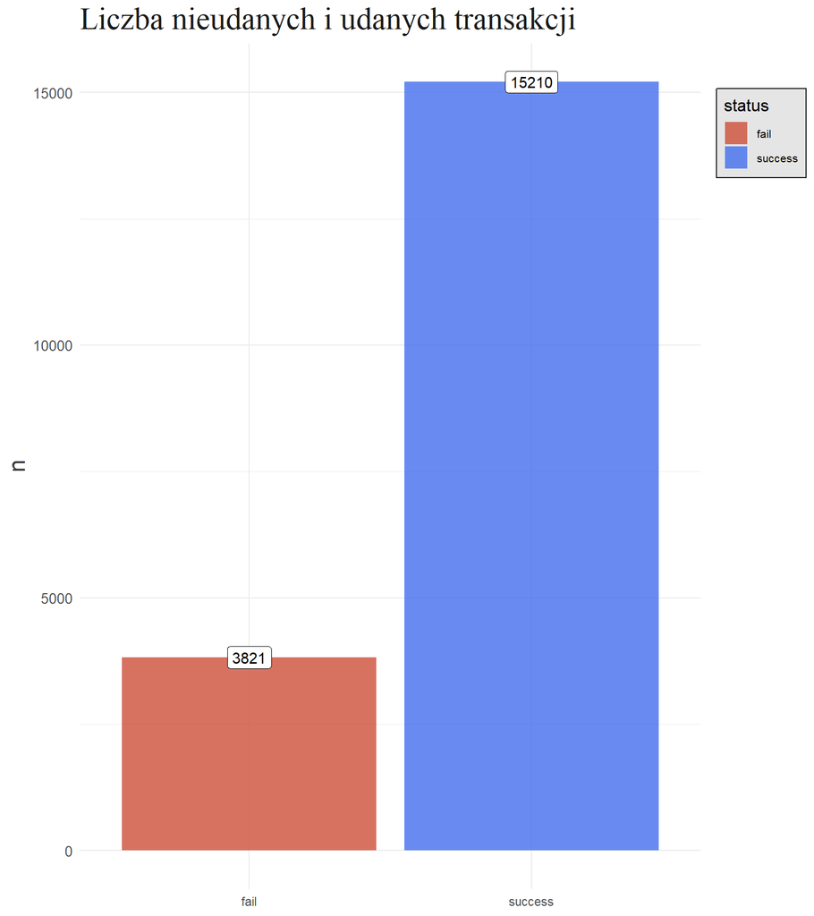

```r
plotStat
```

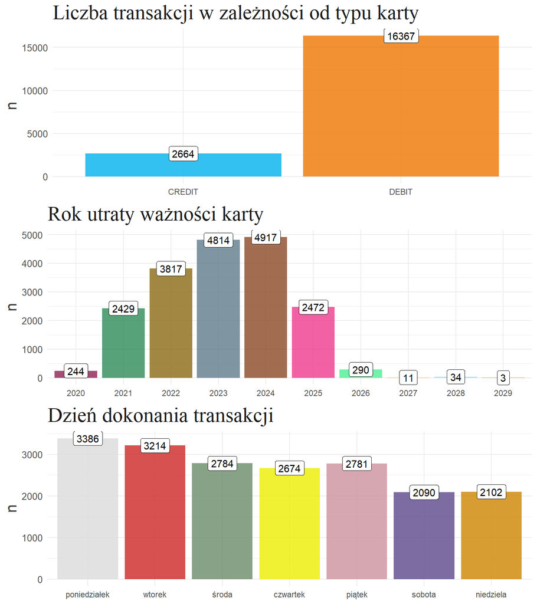

```r
grid.arrange(plotType, plotExpy, plotWeekd)
```

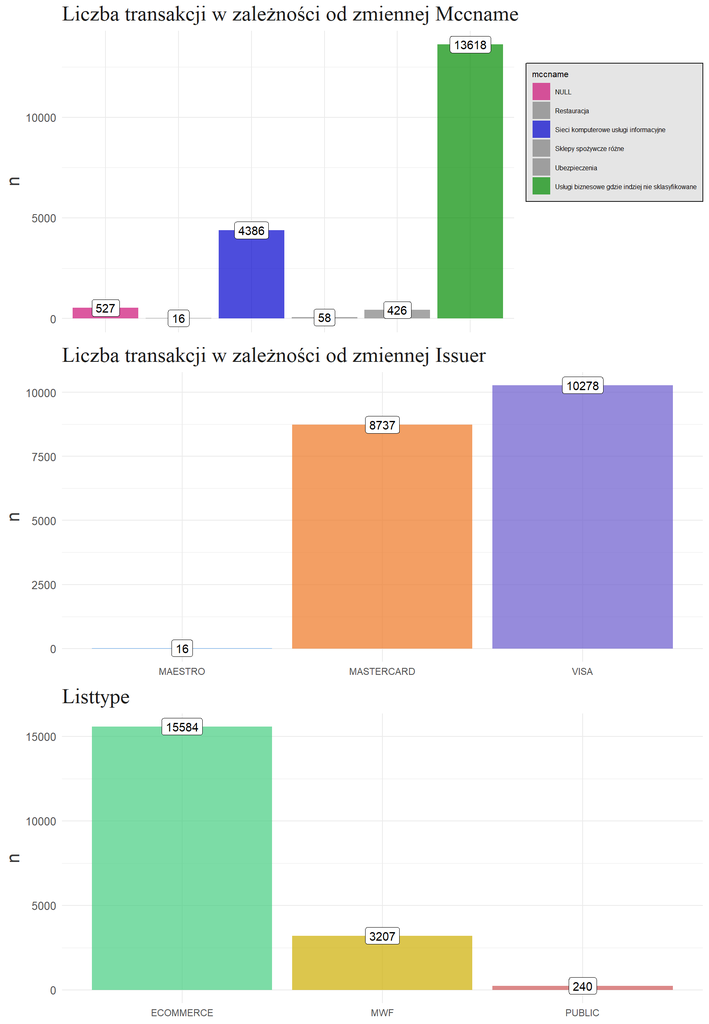

```r
grid.arrange(plotMccname, plotIssuer, plotListt)
```

### Histogramy dla wybranych zmiennych

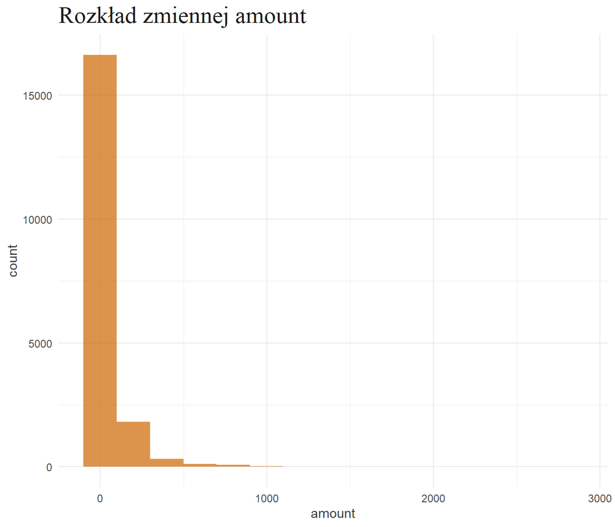

```r
plotAmount
```

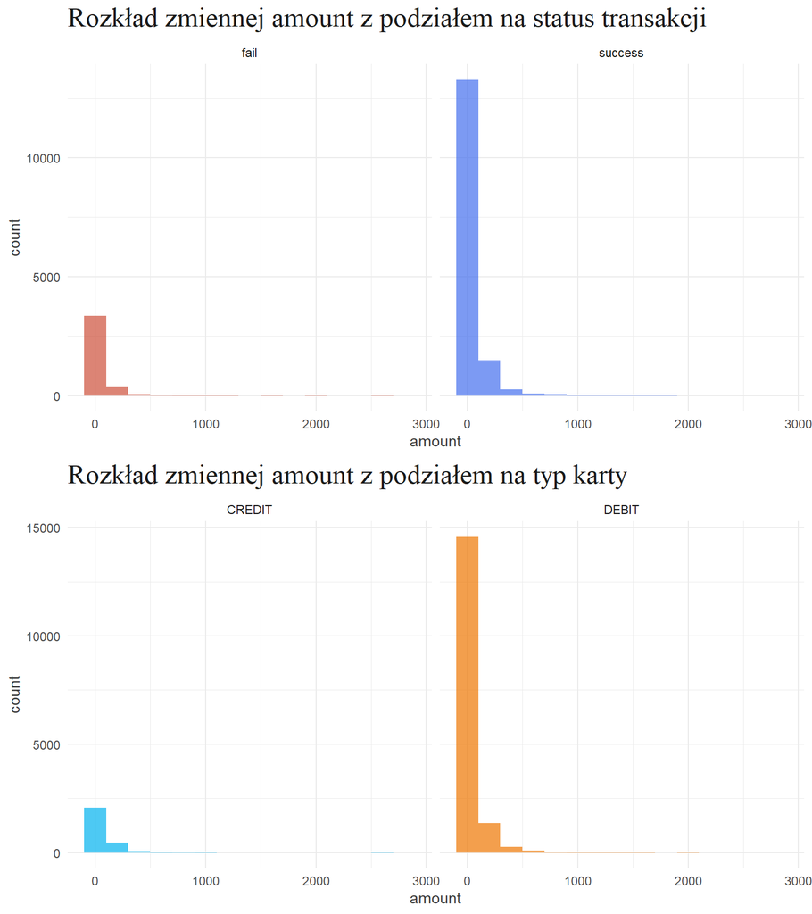

```r
grid.arrange(plotAmStat, plotAmTyp)
```

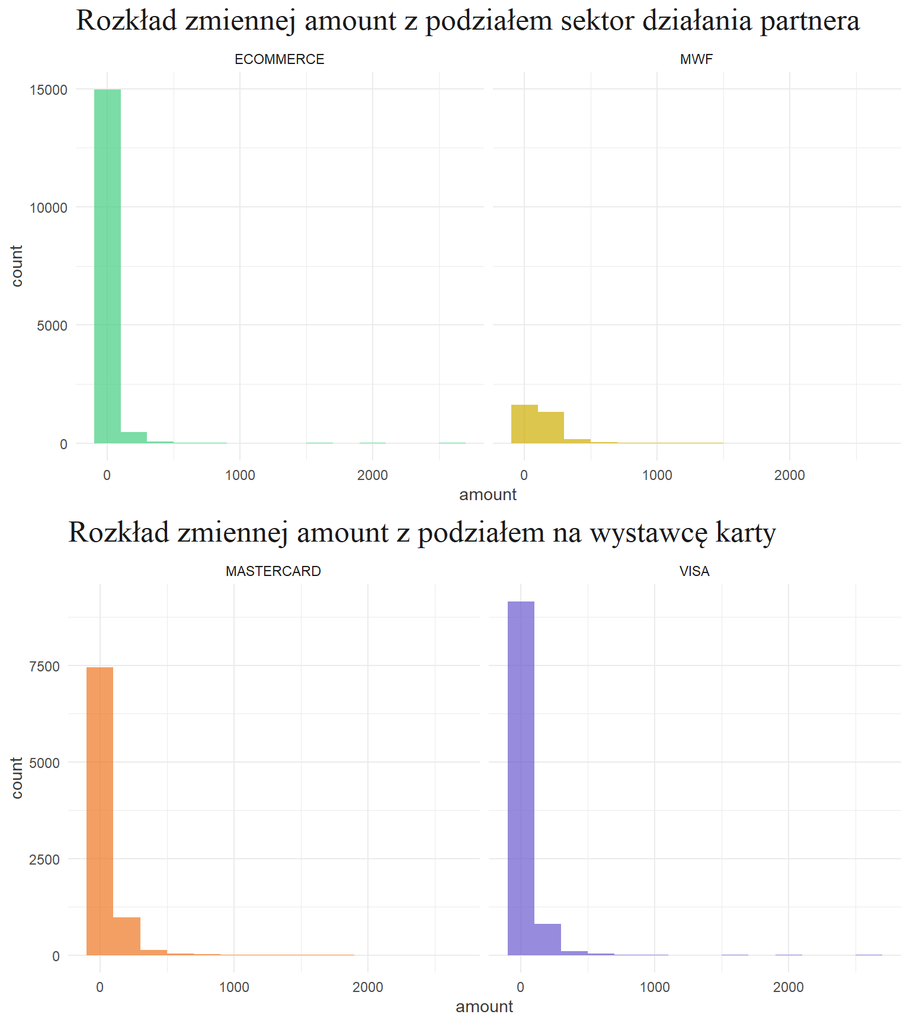

```r
grid.arrange(plotAmListt, plotAmIss)
```

### Eksploracja danych - proba walidacyjna

```r
head(proba_walidacyjna)
```

```
##        id initialtransaction_id          createtime amount browseragent
## 429 49995                    17 2020-11-08 23:13:43  25.00         <NA>
## 476 15135                    20 2020-08-14 09:40:16 115.29         <NA>
## 582 14404                    25 2020-08-12 08:16:03 111.00         <NA>
## 896 16121                    31 2020-08-17 06:46:19 193.25         <NA>
## 897 16808                    31 2020-08-19 06:48:09 167.89         <NA>
## 898 16809                    31 2020-08-19 06:48:13  30.75         <NA>
##         description recurringaction screenheight screenwidth
## 429 Orange On-line:            AUTO         <NA>        <NA>
## 476            <NA>            AUTO         <NA>        <NA>
## 582  PLAY - FAKTURA            AUTO         <NA>        <NA>
## 896            <NA>            AUTO         <NA>        <NA>
## 897            <NA>            AUTO         <NA>        <NA>
## 898            <NA>            AUTO         <NA>        <NA>
##     acquirerconnectionmethod expirymonth expiryyear     issuer   type    level
```

[output cut: 20 more lines]

```r
tail(proba_walidacyjna)
```

```
##            id initialtransaction_id          createtime amount
## 162358 158275                    NA 2021-07-01 13:07:21      1
## 162366 158723                    NA 2021-07-02 07:20:58      1
## 162367 158807                    NA 2021-07-02 09:19:39      1
## 162401 159730                    NA 2021-07-03 17:38:50      1
## 162413 160062                    NA 2021-07-04 12:14:44      1
## 162453 161873                    NA 2021-07-07 05:52:14      1
##                                                                                                                                                                    browseragent
## 162358         Mozilla/5.0 (Linux; Android 11; SM-G985F Build/RP1A.200720.012; wv) AppleWebKit/537.36 (KHTML, like Gecko) Version/4.0 Chrome/91.0.4472.120 Mobile Safari/537.36
## 162366 Mozilla/5.0 (Linux; Android 10; Redmi Note 8 Pro Build/QP1A.190711.020; wv) AppleWebKit/537.36 (KHTML, like Gecko) Version/4.0 Chrome/91.0.4472.120 Mobile Safari/537.36
## 162367                                                            Mozilla/5.0 (iPhone; CPU iPhone OS 14_6 like Mac OS X) AppleWebKit/605.1.15 (KHTML, like Gecko) Mobile/15E148
## 162401       Mozilla/5.0 (Linux; Android 10; M2007J20CG Build/QKQ1.200512.002; wv) AppleWebKit/537.36 (KHTML, like Gecko) Version/4.0 Chrome/87.0.4280.101 Mobile Safari/537.36
## 162413             Mozilla/5.0 (Linux; Android 9; VTR-L09 Build/HUAWEIVTR-L09; wv) AppleWebKit/537.36 (KHTML, like Gecko) Version/4.0 Chrome/91.0.4472.120 Mobile Safari/537.36
## 162453                                                            Mozilla/5.0 (iPhone; CPU iPhone OS 13_7 like Mac OS X) AppleWebKit/605.1.15 (KHTML, like Gecko) Mobile/15E148
##         description  recurringaction screenheight screenwidth
```

[output cut: 20 more lines]

```r
str(proba_walidacyjna)
```

```
## 'data.frame':    7353 obs. of  20 variables:
##  $ id                      : int  49995 15135 14404 16121 16808 16809 28181 31546 39532 40467 ...
##  $ initialtransaction_id   : int  17 20 25 31 31 31 31 31 31 31 ...
##  $ createtime              : POSIXct, format: "2020-11-08 23:13:43" "2020-08-14 09:40:16" ...
##  $ amount                  : num  25 115 111 193 168 ...
##  $ browseragent            : chr  NA NA NA NA ...
##  $ description             : chr  "Orange On-line:" NA "PLAY - FAKTURA" NA ...
##  $ recurringaction         : chr  "AUTO" "AUTO" "AUTO" "AUTO" ...
##  $ screenheight            : chr  NA NA NA NA ...
##  $ screenwidth             : chr  NA NA NA NA ...
##  $ acquirerconnectionmethod: chr  "FDP_SOAP" "FDP_SOAP" "FDP_SOAP" "FDP_SOAP" ...
##  $ expirymonth             : int  12 12 12 12 12 12 12 12 12 12 ...
##  $ expiryyear              : int  2020 2020 2023 2024 2024 2024 2024 2024 2024 2024 ...
##  $ issuer                  : chr  "VISA" "MASTERCARD" "MASTERCARD" "MASTERCARD" ...
##  $ type                    : chr  "DEBIT" "DEBIT" "CREDIT" "CREDIT" ...
##  $ level                   : chr  "CLASSIC" "STANDARD" "STANDARD" "PLATINUM" ...
##  $ countrycode             : chr  "PL" "PL" "PL" "PL" ...
##  $ listtype                : chr  "ECOMMERCE" "MWF" "MWF" "MWF" ...
##  $ mccname                 : chr  "Usługi biznesowe gdzie indziej nie sklasyfikowane" "Usługi biznesowe gdzie indziej nie sklasyfikowane" "Usługi biznesowe gdzie indziej nie sklasyfikowane" "NULL" ...
##  $ payclickedtime          : POSIXct, format: NA NA ...
##  $ status                  : Factor w/ 4 levels "bank declined",..: 4 4 4 4 4 4 4 4 4 4 ...
```

```r
summary(proba_walidacyjna)
```

```
##        id         initialtransaction_id   createtime
##  Min.   :    39   Min.   :    17        Min.   :2020-01-10 09:02:52
##  1st Qu.: 42965   1st Qu.:  1634        1st Qu.:2020-10-22 10:56:16
##  Median : 81317   Median : 25360        Median :2021-01-29 08:09:17
##  Mean   : 81061   Mean   : 37185        Mean   :2021-01-18 09:06:05
##  3rd Qu.:120353   3rd Qu.: 64632        3rd Qu.:2021-04-26 09:50:28
##  Max.   :162454   Max.   :161873        Max.   :2021-07-07 23:17:16
##                   NA's   :933
##      amount        browseragent       description        recurringaction
##  Min.   :   0.81   Length:7353        Length:7353        Length:7353
##  1st Qu.:  17.00   Class :character   Class :character   Class :character
##  Median :  30.00   Mode  :character   Mode  :character   Mode  :character
##  Mean   :  58.60
##  3rd Qu.:  50.00
##  Max.   :2606.37
##
##  screenheight       screenwidth        acquirerconnectionmethod
##  Length:7353        Length:7353        Length:7353
##  Class :character   Class :character   Class :character
##  Mode  :character   Mode  :character   Mode  :character
##
##
##
##
##   expirymonth       expiryyear      issuer              type
##  Min.   : 1.000   Min.   :2020   Length:7353        Length:7353
##  1st Qu.: 3.000   1st Qu.:2022   Class :character   Class :character
##  Median : 7.000   Median :2023   Mode  :character   Mode  :character
##  Mean   : 6.472   Mean   :2023
##  3rd Qu.: 9.000   3rd Qu.:2024
##  Max.   :12.000   Max.   :2029
##
##     level           countrycode          listtype           mccname
##  Length:7353        Length:7353        Length:7353        Length:7353
##  Class :character   Class :character   Class :character   Class :character
##  Mode  :character   Mode  :character   Mode  :character   Mode  :character
##
##
##
##
##  payclickedtime                                   status
##  Min.   :2020-01-10 09:04:57   bank declined         :   9
##  1st Qu.:2020-07-19 11:54:09   card limit exceeded   :1133
##  Median :2020-11-12 16:29:00   do not honor          : 101
##  Mean   :2020-11-04 21:23:56   completed successfully:5177
##  3rd Qu.:2021-02-28 14:17:48   NA's                  : 933
##  Max.   :2021-07-07 05:54:11
##  NA's   :6420
```

### Transformacja danych

Poniżej zostały przedstawione czynności mające na celu transformacje zmiennych za pomocą biblioteki “dplyr”.

```r
proba_walidacyjna$description <- ifelse(proba_walidacyjna$description == "", "Brak opisu", proba_walidacyjna$description)
proba_walidacyjna$description <- ifelse(is.na(proba_walidacyjna$description), "Brak opisu", proba_walidacyjna$description)

proba_walidacyjna <- proba_walidacyjna %>%
  select(id, createtime, amount, description, recurringaction, acquirerconnectionmethod, expirymonth, expiryyear, issuer,
         type, level, countrycode, listtype, mccname, status) %>%
  filter(recurringaction == "AUTO") %>%
  mutate(acquirerconnectionmethod = factor(acquirerconnectionmethod),
         expirymonth = factor(expirymonth),
         description = factor(description),
         expiryyear = factor(expiryyear),
         issuer = factor(issuer),
         type = factor(type),
         level = factor(level),
         countrycode = factor(countrycode),
         listtype = factor(listtype),
         mccname = factor(mccname))

proba_walidacyjna$recurringaction <- NULL

proba_walidacyjna$weekDay <- weekdays(as.Date(proba_walidacyjna$createtime))
proba_walidacyjna$weekDay <- as.factor(proba_walidacyjna$weekDay)
proba_walidacyjna$status <- ifelse(proba_walidacyjna$status == "completed successfully", "success", "fail")
proba_walidacyjna$status <- as.factor(proba_walidacyjna$status)

proba_walidacyjna$weekDay <- factor(proba_walidacyjna$weekDay, levels= c("poniedziałek", "wtorek",
                                                              "środa", "czwartek", "piątek", "sobota", "niedziela"))
```

### Podsumowanie zmian

Zmiany w próbie walidacyjnej oparte były w głównej mierze na wybraniu odpowiednich zmiennych, stworzeniu dodatkowej zmiennej - *weekDay* oraz zamianie czynników w zmiennej *status*.

```r
str(proba_walidacyjna)
```

```
## 'data.frame':    6420 obs. of  15 variables:
##  $ id                      : int  49995 15135 14404 16121 16808 16809 28181 31546 39532 40467 ...
##  $ createtime              : POSIXct, format: "2020-11-08 23:13:43" "2020-08-14 09:40:16" ...
##  $ amount                  : num  25 115 111 193 168 ...
##  $ description             : Factor w/ 11 levels " platnosci za faktury za tv internet telefon",..: 6 3 7 3 3 3 3 3 3 3 ...
##  $ acquirerconnectionmethod: Factor w/ 2 levels "ECARD_REST","FDP_SOAP": 2 2 2 2 2 2 2 2 2 2 ...
##  $ expirymonth             : Factor w/ 12 levels "1","2","3","4",..: 12 12 12 12 12 12 12 12 12 12 ...
##  $ expiryyear              : Factor w/ 10 levels "2020","2021",..: 1 1 4 5 5 5 5 5 5 5 ...
##  $ issuer                  : Factor w/ 3 levels "MAESTRO","MASTERCARD",..: 3 2 2 2 2 2 2 2 2 2 ...
##  $ type                    : Factor w/ 2 levels "CREDIT","DEBIT": 2 2 1 1 1 1 1 1 1 1 ...
##  $ level                   : Factor w/ 22 levels "BUSINESS","CLASSIC",..: 2 18 18 12 12 12 12 12 12 12 ...
##  $ countrycode             : Factor w/ 24 levels "AE","AZ","BY",..: 19 19 19 19 19 19 19 19 19 19 ...
##  $ listtype                : Factor w/ 3 levels "ECOMMERCE","MWF",..: 1 2 2 2 2 2 2 2 2 2 ...
##  $ mccname                 : Factor w/ 7 levels "NULL","Restauracja",..: 7 7 7 1 1 1 1 7 1 7 ...
##  $ status                  : Factor w/ 2 levels "fail","success": 2 2 2 2 2 2 2 2 2 2 ...
##  $ weekDay                 : Factor w/ 7 levels "poniedziałek",..: 7 5 3 1 3 3 4 5 3 5 ...
```

```r
summary(proba_walidacyjna)
```

```
##        id           createtime                      amount
##  Min.   :  2443   Min.   :2020-07-08 00:38:04   Min.   :   0.81
##  1st Qu.: 47417   1st Qu.:2020-11-02 08:06:57   1st Qu.:  25.00
##  Median : 85277   Median :2021-02-08 11:16:27   Median :  30.00
##  Mean   : 84779   Mean   :2021-01-29 04:54:22   Mean   :  61.92
##  3rd Qu.:122387   3rd Qu.:2021-04-30 07:05:11   3rd Qu.:  50.00
##  Max.   :162454   Max.   :2021-07-07 23:17:16   Max.   :2606.37
##
##                    description   acquirerconnectionmethod  expirymonth
##  Brak opisu              :2333   ECARD_REST: 457          8      : 644
##  Orange Flex:            :2071   FDP_SOAP  :5963          2      : 628
##  Orange On-line:         : 912                            9      : 578
##  PLAY - FAKTURA          : 675                            10     : 577
##  Przejazd A4Go           : 340                            5      : 568
##  RedBull Mobile - FAKTURA:  32                            11     : 531
##  (Other)                 :  57                            (Other):2894
##    expiryyear          issuer         type           level       countrycode
##  2024   :1650   MAESTRO   :   7   CREDIT: 892   CLASSIC :2325   PL     :5883
##  2023   :1585   MASTERCARD:2932   DEBIT :5528   STANDARD:2215   GB     : 284
##  2022   :1381   VISA      :3481                 GOLD    : 620   UA     :  84
##  2025   : 833                                   BUSINESS: 560   BY     :  34
##  2021   : 782                                   ELECTRON: 246   US     :  31
##  2026   : 101                                   WORLD   : 129   TR     :  15
##  (Other):  88                                   (Other) : 325   (Other):  89
##       listtype                                                 mccname
##  ECOMMERCE:5234   NULL                                             : 167
##  MWF      :1112   Restauracja                                      :   6
##  PUBLIC   :  74   Sieci komputerowe usługi informacyjne            :1499
##                   Sklepy kosmetyczne                               :   1
##                   Sklepy spożywcze różne                           :  25
##                   Ubezpieczenia                                    : 135
##                   Usługi biznesowe gdzie indziej nie sklasyfikowane:4587
##      status             weekDay
##  fail   :1243   poniedziałek:1108
##  success:5177   wtorek      :1062
##                 środa       : 965
##                 czwartek    : 917
##                 piątek      : 934
##                 sobota      : 727
##                 niedziela   : 707
```

### Eksploracja danych - proba testowa

```r
head(proba_testowa)
```

```
##      id initialtransaction_id          createtime amount browseragent
## 1  2702                     1 2020-07-08 16:50:17     NA         <NA>
## 2 13081                     1 2020-08-08 16:50:14     NA         <NA>
## 3 24953                     1 2020-09-08 16:50:09     NA         <NA>
## 4 37326                     1 2020-10-08 16:50:17     NA         <NA>
## 5 49909                     1 2020-11-08 16:50:22     NA         <NA>
## 6 61613                     1 2020-12-08 16:50:28     NA         <NA>
##       description recurringaction screenheight screenwidth
## 1 Orange On-line:            AUTO         <NA>        <NA>
## 2 Orange On-line:            AUTO         <NA>        <NA>
## 3 Orange On-line:            AUTO         <NA>        <NA>
## 4 Orange On-line:            AUTO         <NA>        <NA>
## 5 Orange On-line:            AUTO         <NA>        <NA>
## 6    Orange Flex:            AUTO         <NA>        <NA>
##   acquirerconnectionmethod expirymonth expiryyear issuer  type   level
```

[output cut: 20 more lines]

```r
tail(proba_testowa)
```

```
##            id initialtransaction_id          createtime amount
## 162445 161595                    NA 2021-07-06 15:19:52      1
## 162447 161626                    NA 2021-07-06 16:03:57      1
## 162454 161880                    NA 2021-07-07 06:11:31      1
## 162456 161941                    NA 2021-07-07 07:15:01      1
## 162460 162087                    NA 2021-07-07 10:58:28      1
## 162464 162175                    NA 2021-07-07 13:49:20      1
##                                                                                                                                                            browseragent
## 162445                                                    Mozilla/5.0 (iPhone; CPU iPhone OS 14_6 like Mac OS X) AppleWebKit/605.1.15 (KHTML, like Gecko) Mobile/15E148
## 162447                                                    Mozilla/5.0 (iPhone; CPU iPhone OS 14_6 like Mac OS X) AppleWebKit/605.1.15 (KHTML, like Gecko) Mobile/15E148
## 162454 Mozilla/5.0 (Linux; Android 11; SM-M515F Build/RP1A.200720.012; wv) AppleWebKit/537.36 (KHTML, like Gecko) Version/4.0 Chrome/90.0.4430.210 Mobile Safari/537.36
## 162456 Mozilla/5.0 (Linux; Android 10; SM-G965F Build/QP1A.190711.020; wv) AppleWebKit/537.36 (KHTML, like Gecko) Version/4.0 Chrome/91.0.4472.120 Mobile Safari/537.36
## 162460                                                    Mozilla/5.0 (iPhone; CPU iPhone OS 14_6 like Mac OS X) AppleWebKit/605.1.15 (KHTML, like Gecko) Mobile/15E148
## 162464                                                    Mozilla/5.0 (iPhone; CPU iPhone OS 14_6 like Mac OS X) AppleWebKit/605.1.15 (KHTML, like Gecko) Mobile/15E148
##         description  recurringaction screenheight screenwidth
```

[output cut: 20 more lines]

```r
str(proba_testowa)
```

```
## 'data.frame':    15185 obs. of  19 variables:
##  $ id                      : int  2702 13081 24953 37326 49909 61613 73671 85455 97474 112341 ...
##  $ initialtransaction_id   : int  1 1 1 1 1 1 1 1 1 1 ...
##  $ createtime              : POSIXct, format: "2020-07-08 16:50:17" "2020-08-08 16:50:14" ...
##  $ amount                  : num  NA NA NA NA NA NA NA NA NA NA ...
##  $ browseragent            : chr  NA NA NA NA ...
##  $ description             : chr  "Orange On-line:" "Orange On-line:" "Orange On-line:" "Orange On-line:" ...
##  $ recurringaction         : chr  "AUTO" "AUTO" "AUTO" "AUTO" ...
##  $ screenheight            : chr  NA NA NA NA ...
##  $ screenwidth             : chr  NA NA NA NA ...
##  $ acquirerconnectionmethod: chr  "FDP_SOAP" "FDP_SOAP" "FDP_SOAP" "FDP_SOAP" ...
##  $ expirymonth             : int  1 1 1 1 1 1 1 1 1 1 ...
##  $ expiryyear              : int  2025 2025 2025 2025 2025 2025 2025 2025 2025 2025 ...
##  $ issuer                  : chr  "VISA" "VISA" "VISA" "VISA" ...
##  $ type                    : chr  "DEBIT" "DEBIT" "DEBIT" "DEBIT" ...
##  $ level                   : chr  "PREPAID" "PREPAID" "PREPAID" "PREPAID" ...
##  $ countrycode             : chr  "PL" "PL" "PL" "PL" ...
##  $ listtype                : chr  "ECOMMERCE" "ECOMMERCE" "ECOMMERCE" "ECOMMERCE" ...
##  $ mccname                 : chr  "Usługi biznesowe gdzie indziej nie sklasyfikowane" "Usługi biznesowe gdzie indziej nie sklasyfikowane" "Usługi biznesowe gdzie indziej nie sklasyfikowane" "Usługi biznesowe gdzie indziej nie sklasyfikowane" ...
##  $ payclickedtime          : POSIXct, format: NA NA ...
```

```r
summary(proba_testowa)
```

```
##        id         initialtransaction_id   createtime
##  Min.   :     1   Min.   :     1        Min.   :2020-01-08 01:53:59
##  1st Qu.: 46869   1st Qu.:  2122        1st Qu.:2020-10-31 14:03:31
##  Median : 80559   Median : 29200        Median :2021-01-27 13:43:25
##  Mean   : 82061   Mean   : 37889        Mean   :2021-01-21 03:52:11
##  3rd Qu.:120269   3rd Qu.: 58451        3rd Qu.:2021-04-26 08:15:43
##  Max.   :162456   Max.   :162175        Max.   :2021-07-07 23:28:02
##                   NA's   :1698
##      amount        browseragent       description        recurringaction
##  Min.   :   1.00   Length:15185       Length:15185       Length:15185
##  1st Qu.:   1.00   Class :character   Class :character   Class :character
##  Median :   1.00   Mode  :character   Mode  :character   Mode  :character
##  Mean   :  40.17
##  3rd Qu.:  10.00
##  Max.   :3585.49
##  NA's   :13487
##  screenheight       screenwidth        acquirerconnectionmethod
##  Length:15185       Length:15185       Length:15185
##  Class :character   Class :character   Class :character
##  Mode  :character   Mode  :character   Mode  :character
##
##
##
##
##   expirymonth       expiryyear      issuer              type
##  Min.   : 1.000   Min.   :2020   Length:15185       Length:15185
##  1st Qu.: 3.000   1st Qu.:2022   Class :character   Class :character
##  Median : 7.000   Median :2023   Mode  :character   Mode  :character
##  Mean   : 6.298   Mean   :2023
##  3rd Qu.: 9.000   3rd Qu.:2024
##  Max.   :12.000   Max.   :2029
##
##     level           countrycode          listtype           mccname
##  Length:15185       Length:15185       Length:15185       Length:15185
##  Class :character   Class :character   Class :character   Class :character
##  Mode  :character   Mode  :character   Mode  :character   Mode  :character
##
##
##
##
##  payclickedtime
##  Min.   :2020-01-08 01:54:25
##  1st Qu.:2020-07-15 19:58:26
##  Median :2020-11-09 08:55:10
##  Mean   :2020-11-02 18:43:58
##  3rd Qu.:2021-02-22 18:15:45
##  Max.   :2021-07-07 13:50:28
##  NA's   :13487
```

### Transformacja danych

Poniżej zostały przedstawione czynności mające na celu transformacje zmiennych za pomocą biblioteki “dplyr”.

```r
proba_testowa$description <- ifelse(proba_testowa$description == "", "Brak opisu", proba_testowa$description)
proba_testowa$description <- ifelse(is.na(proba_testowa$description), "Brak opisu", proba_testowa$description)

proba_testowa <- proba_testowa %>%
  select(id, createtime, description, recurringaction, acquirerconnectionmethod, expirymonth, expiryyear, issuer,
         type, level, countrycode, listtype, mccname) %>%
  filter(recurringaction == "AUTO") %>%
  mutate(acquirerconnectionmethod = factor(acquirerconnectionmethod),
         expirymonth = factor(expirymonth),
         description = factor(description),
         expiryyear = factor(expiryyear),
         issuer = factor(issuer),
         type = factor(type),
         level = factor(level),
         countrycode = factor(countrycode),
         listtype = factor(listtype),
         mccname = factor(mccname))

proba_testowa$recurringaction <- NULL

proba_testowa$weekDay <- weekdays(as.Date(proba_testowa$createtime))
proba_testowa$weekDay <- as.factor(proba_testowa$weekDay)
proba_testowa$weekDay <- factor(proba_testowa$weekDay, levels= c("poniedziałek", "wtorek",
                                                               "środa", "czwartek", "piątek", "sobota", "niedziela"))
```

### Podsumowanie zmian

Zmiany polegały głównie na wybraniu odpowiednich zmiennych do próby testowej oraz na stworzeniu dodatkowej zmiennej - *weekDay*.

```r
str(proba_testowa)
```

```
## 'data.frame':    13484 obs. of  13 variables:
##  $ id                      : int  2702 13081 24953 37326 49909 61613 73671 85455 97474 112341 ...
##  $ createtime              : POSIXct, format: "2020-07-08 16:50:17" "2020-08-08 16:50:14" ...
##  $ description             : Factor w/ 11 levels " platnosci za faktury za tv internet telefon",..: 6 6 6 6 6 5 5 5 5 5 ...
##  $ acquirerconnectionmethod: Factor w/ 2 levels "ECARD_REST","FDP_SOAP": 2 2 2 2 2 2 2 2 2 2 ...
##  $ expirymonth             : Factor w/ 12 levels "1","2","3","4",..: 1 1 1 1 1 1 1 1 1 1 ...
##  $ expiryyear              : Factor w/ 9 levels "2020","2021",..: 6 6 6 6 6 6 6 6 6 6 ...
##  $ issuer                  : Factor w/ 3 levels "MAESTRO","MASTERCARD",..: 3 3 3 3 3 3 3 3 3 3 ...
##  $ type                    : Factor w/ 2 levels "CREDIT","DEBIT": 2 2 2 2 2 2 2 2 2 2 ...
##  $ level                   : Factor w/ 23 levels "BUSINESS","CLASSIC",..: 12 12 12 12 12 12 12 12 12 12 ...
##  $ countrycode             : Factor w/ 24 levels "AZ","BY","CH",..: 17 17 17 17 17 17 17 17 17 17 ...
##  $ listtype                : Factor w/ 3 levels "ECOMMERCE","MWF",..: 1 1 1 1 1 1 1 1 1 1 ...
##  $ mccname                 : Factor w/ 6 levels "NULL","Restauracja",..: 6 6 6 6 6 6 6 6 6 6 ...
##  $ weekDay                 : Factor w/ 7 levels "poniedziałek",..: 3 6 2 4 7 2 5 1 1 4 ...
```

```r
summary(proba_testowa)
```

```
##        id           createtime                                    description
##  Min.   :  2445   Min.   :2020-07-08 00:59:09   Brak opisu              :4123
##  1st Qu.: 51208   1st Qu.:2020-11-12 02:23:25   Orange Flex:            :3996
##  Median : 84490   Median :2021-02-06 08:12:10   Przejazd A4Go           :2655
##  Mean   : 85539   Mean   :2021-01-31 03:09:19   Orange On-line:         :1492
##  3rd Qu.:122363   3rd Qu.:2021-04-30 06:32:23   PLAY - FAKTURA          :1004
##  Max.   :162456   Max.   :2021-07-07 23:28:02   RedBull Mobile - FAKTURA: 103
##                                                 (Other)                 : 111
##  acquirerconnectionmethod  expirymonth     expiryyear          issuer
##  ECARD_REST:  778         1      :1701   2023   :3420   MAESTRO   :  12
##  FDP_SOAP  :12706         9      :1504   2024   :3036   MASTERCARD:6996
##                           10     :1380   2022   :2656   VISA      :6476
##                           3      :1199   2021   :2349
##                           7      :1164   2025   :1724
##                           4      :1103   2026   : 171
##                           (Other):5433   (Other): 128
##      type             level       countrycode         listtype
##  CREDIT: 1542   CLASSIC  :4407   PL     :12485   ECOMMERCE:11456
##  DEBIT :11942   STANDARD :3667   GB     :  513   MWF      : 1892
##                 BUSINESS :2052   UA     :   91   PUBLIC   :  136
##                 GOLD     :1160   US     :   80
##                 CORPORATE: 920   IE     :   65
##                 ELECTRON : 339   BY     :   54
##                 (Other)  : 939   (Other):  196
##                                               mccname              weekDay
##  NULL                                             :  309   poniedziałek:2371
##  Restauracja                                      :    4   wtorek      :2221
##  Sieci komputerowe usługi informacyjne            : 2721   środa       :2055
##  Sklepy spożywcze różne                           :  110   czwartek    :1917
##  Ubezpieczenia                                    :   93   piątek      :2047
##  Usługi biznesowe gdzie indziej nie sklasyfikowane:10247   sobota      :1398
##                                                            niedziela   :1475
```

### Ujednolicenie poziomów zmiennych typu “factor” w celu pozbycia się błędów przy korzystaniu z niektórych funkcji

Ujednolicenie poziomów zmiennych typu “factor” było koniecznie, aby poprawnie zadziałały niektóre funkcje do budowy modeli nieparametrycznych. Bez takiego zabiegu pojawiały się błędy związane z różnicą tych czynników.

```r
proba_testowa$expiryyear <- factor(proba_testowa$expiryyear, levels = levels(nowa_uczaca$expiryyear))
proba_testowa$description <- factor(proba_testowa$description, levels = levels(nowa_uczaca$description))
proba_testowa$expirymonth  <- factor(proba_testowa$expirymonth , levels = levels(nowa_uczaca$expirymonth))
proba_testowa$issuer <- factor(proba_testowa$issuer, levels = levels(nowa_uczaca$issuer))
proba_testowa$level <- factor(proba_testowa$level, levels = levels(nowa_uczaca$level))
proba_testowa$countrycode <- factor(proba_testowa$countrycode, levels = levels(nowa_uczaca$countrycode))
proba_testowa$mccname <- factor(proba_testowa$mccname, levels = levels(nowa_uczaca$mccname))
proba_testowa$weekDay <- factor(proba_testowa$weekDay, levels = levels(nowa_uczaca$weekDay))
proba_testowa$listtype <- factor(proba_testowa$listtype, levels = levels(nowa_uczaca$listtype))
proba_testowa$acquirerconnectionmethod <- factor(proba_testowa$acquirerconnectionmethod, levels = levels(nowa_uczaca$acquirerconnectionmethod))
proba_testowa$type <- factor(proba_testowa$type, levels = levels(nowa_uczaca$type))

proba_walidacyjna$expiryyear <- factor(proba_walidacyjna$expiryyear, levels = levels(nowa_uczaca$expiryyear))
proba_walidacyjna$description <- factor(proba_walidacyjna$description, levels = levels(nowa_uczaca$description))
proba_walidacyjna$expirymonth  <- factor(proba_walidacyjna$expirymonth , levels = levels(nowa_uczaca$expirymonth))
proba_walidacyjna$issuer <- factor(proba_walidacyjna$issuer, levels = levels(nowa_uczaca$issuer))
proba_walidacyjna$level <- factor(proba_walidacyjna$level, levels = levels(nowa_uczaca$level))
proba_walidacyjna$countrycode <- factor(proba_walidacyjna$countrycode, levels = levels(nowa_uczaca$countrycode))
proba_walidacyjna$mccname <- factor(proba_walidacyjna$mccname, levels = levels(nowa_uczaca$mccname))
proba_walidacyjna$weekDay <- factor(proba_walidacyjna$weekDay, levels = levels(nowa_uczaca$weekDay))
proba_walidacyjna$listtype <- factor(proba_walidacyjna$listtype, levels = levels(nowa_uczaca$listtype))
proba_walidacyjna$acquirerconnectionmethod <- factor(proba_walidacyjna$acquirerconnectionmethod, levels = levels(nowa_uczaca$acquirerconnectionmethod))
proba_walidacyjna$type <- factor(proba_walidacyjna$type, levels = levels(nowa_uczaca$type))

nowa_uczaca <- na.omit(nowa_uczaca)
proba_walidacyjna <- na.omit(proba_walidacyjna)
proba_testowa <- na.omit(proba_testowa)

summary(nowa_uczaca)
```

```
##        id           createtime                      amount
##  Min.   :  2441   Min.   :2020-07-08 00:30:31   Min.   :   0.96
##  1st Qu.: 48517   1st Qu.:2020-11-04 20:55:39   1st Qu.:  25.00
##  Median : 86618   Median :2021-02-11 15:56:39   Median :  30.00
##  Mean   : 85436   Mean   :2021-01-30 16:52:48   Mean   :  63.92
##  3rd Qu.:123798   3rd Qu.:2021-05-03 08:18:17   3rd Qu.:  50.00
##  Max.   :162463   Max.   :2021-07-07 23:51:06   Max.   :2712.64
##
##                    description   acquirerconnectionmethod  expirymonth
##  Brak opisu              :6852   ECARD_REST: 1391         2      :1828
##  Orange Flex:            :6267   FDP_SOAP  :17640         9      :1827
##  Orange On-line:         :2698                            8      :1820
##  PLAY - FAKTURA          :1891                            10     :1713
##  Przejazd A4Go           :1046                            1      :1567
##  RedBull Mobile - FAKTURA:  92                            5      :1566
##  (Other)                 : 185                            (Other):8710
##    expiryyear          issuer          type            level
##  2024   :4917   MAESTRO   :   16   CREDIT: 2664   CLASSIC :6899
##  2023   :4814   MASTERCARD: 8737   DEBIT :16367   STANDARD:6585
##  2022   :3817   VISA      :10278                  GOLD    :1838
##  2025   :2472                                     BUSINESS:1674
##  2021   :2429                                     ELECTRON: 684
##  2026   : 290                                     WORLD   : 414
##  (Other): 292                                     (Other) : 937
##   countrycode         listtype
##  PL     :17309   ECOMMERCE:15584
##  GB     :  892   MWF      : 3207
##  UA     :  268   PUBLIC   :  240
##  BY     :  110
##  US     :  105
##  TR     :   62
##  (Other):  285
##                                               mccname          status
##  NULL                                             :  527   fail   : 3821
##  Restauracja                                      :   16   success:15210
##  Sieci komputerowe usługi informacyjne            : 4386
##  Sklepy spożywcze różne                           :   58
##  Ubezpieczenia                                    :  426
##  Usługi biznesowe gdzie indziej nie sklasyfikowane:13618
##
##          weekDay
##  poniedziałek:3386
##  wtorek      :3214
##  środa       :2784
##  czwartek    :2674
##  piątek      :2781
##  sobota      :2090
##  niedziela   :2102
```

```r
summary(proba_walidacyjna)
```

```
##        id           createtime                      amount
##  Min.   :  2443   Min.   :2020-07-08 00:38:04   Min.   :   0.81
##  1st Qu.: 47415   1st Qu.:2020-11-02 08:06:23   1st Qu.:  25.00
##  Median : 85272   Median :2021-02-08 11:04:45   Median :  30.00
##  Mean   : 84772   Mean   :2021-01-29 04:28:09   Mean   :  61.92
##  3rd Qu.:122383   3rd Qu.:2021-04-30 06:59:52   3rd Qu.:  50.00
##  Max.   :162454   Max.   :2021-07-07 23:17:16   Max.   :2606.37
##
##                    description   acquirerconnectionmethod  expirymonth
##  Brak opisu              :2332   ECARD_REST: 457          8      : 644
##  Orange Flex:            :2070   FDP_SOAP  :5961          2      : 628
##  Orange On-line:         : 912                            9      : 578
##  PLAY - FAKTURA          : 675                            10     : 576
##  Przejazd A4Go           : 340                            5      : 568
##  RedBull Mobile - FAKTURA:  32                            11     : 531
##  (Other)                 :  57                            (Other):2893
##    expiryyear          issuer         type           level       countrycode
##  2024   :1649   MAESTRO   :   7   CREDIT: 891   CLASSIC :2324   PL     :5882
##  2023   :1584   MASTERCARD:2931   DEBIT :5527   STANDARD:2214   GB     : 284
##  2022   :1381   VISA      :3480                 GOLD    : 620   UA     :  84
##  2025   : 833                                   BUSINESS: 560   BY     :  34
##  2021   : 782                                   ELECTRON: 246   US     :  31
##  2026   : 101                                   WORLD   : 129   TR     :  15
##  (Other):  88                                   (Other) : 325   (Other):  88
##       listtype                                                 mccname
##  ECOMMERCE:5232   NULL                                             : 167
##  MWF      :1112   Restauracja                                      :   6
##  PUBLIC   :  74   Sieci komputerowe usługi informacyjne            :1499
##                   Sklepy spożywcze różne                           :  25
##                   Ubezpieczenia                                    : 135
##                   Usługi biznesowe gdzie indziej nie sklasyfikowane:4586
##
##      status             weekDay
##  fail   :1242   poniedziałek:1108
##  success:5176   wtorek      :1062
##                 środa       : 965
##                 czwartek    : 917
##                 piątek      : 934
##                 sobota      : 727
##                 niedziela   : 705
```

```r
summary(proba_testowa)
```

```
##        id           createtime                                    description
##  Min.   :  2445   Min.   :2020-07-08 00:59:09   Brak opisu              :4108
##  1st Qu.: 51214   1st Qu.:2020-11-12 03:51:55   Orange Flex:            :3980
##  Median : 84543   Median :2021-02-06 11:13:30   Przejazd A4Go           :2655
##  Mean   : 85559   Mean   :2021-01-31 04:14:08   Orange On-line:         :1486
##  3rd Qu.:122376   3rd Qu.:2021-04-30 06:47:57   PLAY - FAKTURA          :1004
##  Max.   :162456   Max.   :2021-07-07 23:28:02   RedBull Mobile - FAKTURA: 103
##                                                 (Other)                 : 110
##  acquirerconnectionmethod  expirymonth     expiryyear          issuer
##  ECARD_REST:  772         1      :1701   2023   :3407   MAESTRO   :  12
##  FDP_SOAP  :12674         9      :1491   2024   :3029   MASTERCARD:6996
##                           10     :1380   2022   :2656   VISA      :6438
##                           3      :1199   2021   :2346
##                           7      :1164   2025   :1709
##                           4      :1097   2026   : 171
##                           (Other):5414   (Other): 128
##      type             level       countrycode         listtype
##  CREDIT: 1523   CLASSIC  :4389   PL     :12482   ECOMMERCE:11425
##  DEBIT :11923   STANDARD :3667   GB     :  513   MWF      : 1885
##                 BUSINESS :2052   UA     :   91   PUBLIC   :  136
##                 GOLD     :1151   US     :   80
##                 CORPORATE: 920   IE     :   65
##                 ELECTRON : 339   BY     :   54
##                 (Other)  : 928   (Other):  161
##                                               mccname              weekDay
##  NULL                                             :  309   poniedziałek:2366
##  Restauracja                                      :    4   wtorek      :2212
##  Sieci komputerowe usługi informacyjne            : 2712   środa       :2051
##  Sklepy spożywcze różne                           :  110   czwartek    :1913
##  Ubezpieczenia                                    :   93   piątek      :2038
##  Usługi biznesowe gdzie indziej nie sklasyfikowane:10218   sobota      :1396
##                                                            niedziela   :1470
```

```r
proba_testowa_final <- proba_testowa

nowa_uczaca$amount <- NULL
proba_walidacyjna$amount <- NULL
```

## **ZADANIE 1. Budowa modelu w oparciu o zmienną jakościową “status”**

### Funkcja do obliczania logarytmu wiarygodności

Poniższa funkcja została została napisana, aby poprawnie policzyć logarytm wiarygodności uzyskany za pomocą oszacowanych modeli.

```r
loglikelihood <- function(y, py) {
  pysmooth <- ifelse(py == 0, 1e-12,
                     ifelse(py == 1, 1 - 1e-12, py))

  sum(y * log(pysmooth) + (1 - y) * log(1 - pysmooth))

}
```

### Funkcja obliczająca i zwracająca znormalizowaną dewiancję, dokładność predykcyjną i wynik f1

Kolejna funkcja ma za zadanie obliczyć miarę dokładności, precyzji oraz f1 dla zbudowanych modeli na podstawie predykcji w oparciu o prawdopodobieństwa.

```r
miaryDokladnosci <- function(pred, truth, name = "model") {
  dev.norm <- -2 * loglikelihood(as.numeric(truth), pred) / length(pred)
  ctable <- table(truth = truth,
                  pred = (pred > 0.5))
  accuracy <- sum(diag(ctable)) / sum(ctable)
  precision <- ctable[2,2] / sum(ctable[2,])
  recall <- ctable[2,2] / sum(ctable[2,])
  f1 <- 2 * precision * recall / (precision + recall)
  data.frame(model = name, accuracy = accuracy, f1 = f1, dev.norm)
}
```

### Zbudowanie maksymalnego drzewa klasyfikacyjnego z parametrem cp = 0

W pierwszym etapie badania zbudowano maksymalne drzewo klasyfikacyjne, którego stopień rozbudowania uniemożliwia interpretację.

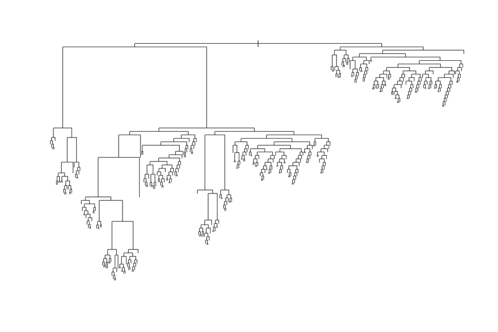

```r
statusTree <- rpart(formula = status ~ . - id - createtime,
                data=nowa_uczaca,
                cp = 0, xval = 10)

plot(statusTree)
```

### Obliczanie błędów na bazie sprawdzania krzyżowego

W celu zredukowania wymiarowości drzewa, obliczono błędy na bazie sprawdzania krzyżowego i na tej podstawie określono optymalny numer drzewa. Jak widać na poniższych wykresach, wartości błędów “wypłaszczają się” już od około 60 podziału, choć już od wartości około 20, tempo spadku wartości błędu jest wyraźnie mniejsze.

```r
bledy <- printcp(statusTree)
```

```
##
## Classification tree:
## rpart(formula = status ~ . - id - createtime, data = nowa_uczaca,
##     cp = 0, xval = 10)
##
## Variables actually used in tree construction:
##  [1] acquirerconnectionmethod countrycode              description
##  [4] expirymonth              expiryyear               issuer
##  [7] level                    listtype                 mccname
## [10] type                     weekDay
##
## Root node error: 3821/19031 = 0.20078
##
## n= 19031
##
```

[output cut: 48 more lines]

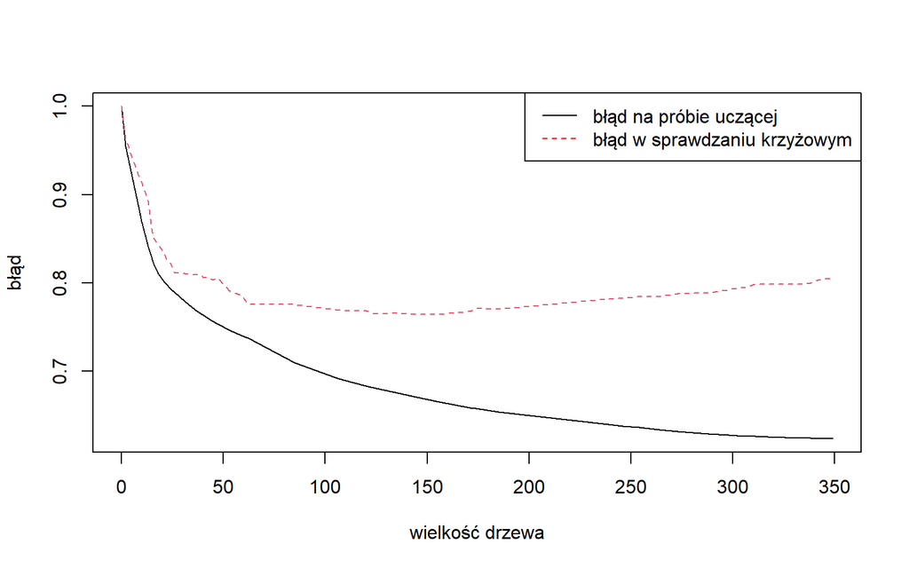

```r
matplot(x = bledy[, "nsplit"],
        y = bledy[, c("rel error",
                      "xerror")],
        type = "l",
        xlab = "wielkość drzewa",
        ylab = "błąd")
legend(x = "topright", legend = c("błąd na próbie uczącej",
                                  "błąd w sprawdzaniu krzyżowym"),
       col = c("black", "red"),
       lty = 1:2)
```

```r
statusTree$cptable
```

```
##              CP nsplit rel error    xerror       xstd
## 1  2.276891e-02      0 1.0000000 1.0000000 0.01446256
## 2  1.094827e-02      2 0.9544622 0.9633604 0.01426032
## 3  9.552473e-03      8 0.8887726 0.9230568 0.01402868
## 4  9.334380e-03     10 0.8696676 0.9146820 0.01397930
## 5  7.458780e-03     13 0.8416645 0.8932217 0.01385074
## 6  6.019367e-03     15 0.8267469 0.8578906 0.01363259
## 7  5.234232e-03     16 0.8207276 0.8500393 0.01358298
## 8  3.053302e-03     18 0.8102591 0.8434965 0.01354131
## 9  2.878828e-03     21 0.8010992 0.8332897 0.01347573
## 10 2.617116e-03     22 0.7982204 0.8264852 0.01343160
## 11 2.093693e-03     24 0.7929861 0.8217744 0.01340086
## 12 1.962837e-03     26 0.7887987 0.8113059 0.01333198
## 13 1.779639e-03     31 0.7788537 0.8102591 0.01332504
## 14 1.657507e-03     36 0.7699555 0.8089505 0.01331637
```

[output cut: 33 more lines]

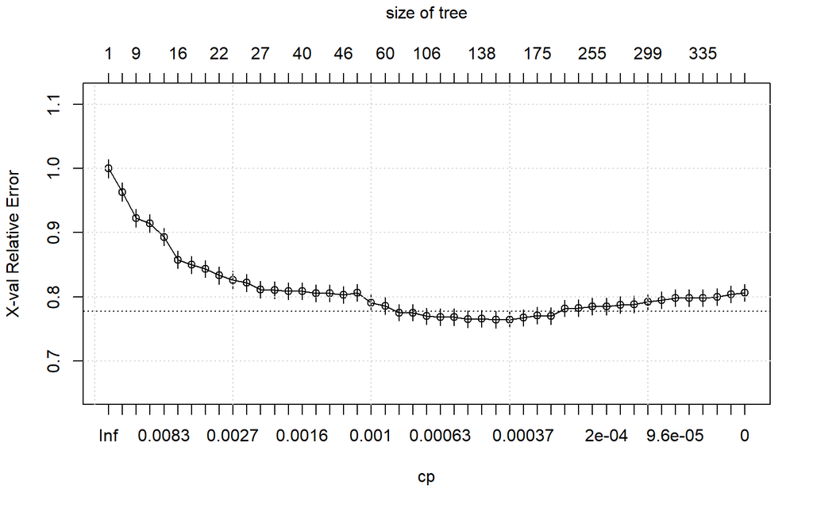

```r
plotcp(statusTree)

grid()
```

### Ustalanie optymalnego numeru drzewa

Przycinanie drzewa (wybór najmniejszego drzewa, którego błąd w sprawdzaniu krzyżowym jest większy od minimalnego błędu nie więcej niż o jedno odchylenie standardowe) wskazało na gałąź nr 22.

```r
bledy <- statusTree$cptable
tmp1 <- which.min(bledy[, "xerror"])
tmp2 <- sum(bledy[tmp1, c("xerror", "xstd")])
optymalny <- which(bledy[, "xerror"] < tmp2)[1]

statusTree.p <- prune(statusTree, cp = bledy[optymalny, "CP"])
statusTree.p$cptable
```

```
##              CP nsplit rel error    xerror       xstd
## 1  0.0227689087      0 1.0000000 1.0000000 0.01446256
## 2  0.0109482683      2 0.9544622 0.9633604 0.01426032
## 3  0.0095524732      8 0.8887726 0.9230568 0.01402868
## 4  0.0093343802     10 0.8696676 0.9146820 0.01397930
## 5  0.0074587804     13 0.8416645 0.8932217 0.01385074
## 6  0.0060193667     15 0.8267469 0.8578906 0.01363259
## 7  0.0052342319     16 0.8207276 0.8500393 0.01358298
## 8  0.0030533019     18 0.8102591 0.8434965 0.01354131
## 9  0.0028788275     21 0.8010992 0.8332897 0.01347573
## 10 0.0026171159     22 0.7982204 0.8264852 0.01343160
## 11 0.0020936928     24 0.7929861 0.8217744 0.01340086
## 12 0.0019628370     26 0.7887987 0.8113059 0.01333198
## 13 0.0017796388     31 0.7788537 0.8102591 0.01332504
## 14 0.0016575068     36 0.7699555 0.8089505 0.01331637
## 15 0.0015702696     39 0.7649830 0.8089505 0.01331637
## 16 0.0014830324     40 0.7634127 0.8055483 0.01329375
## 17 0.0014394138     43 0.7589636 0.8055483 0.01329375
## 18 0.0013085580     45 0.7560848 0.8031929 0.01327805
## 19 0.0011777022     47 0.7534677 0.8060717 0.01329724
## 20 0.0009159906     53 0.7461398 0.7903690 0.01319182
## 21 0.0008723720     59 0.7401204 0.7859199 0.01316162
## 22 0.0008505627     62 0.7375033 0.7754515 0.01308998
```

### Wykres przyciętego drzewa

Przycięcie drzewa zredukowało jego wymiarowość, choć wciąż jest to drzewo stosunkowo rozbudowane z 62 podziałami.

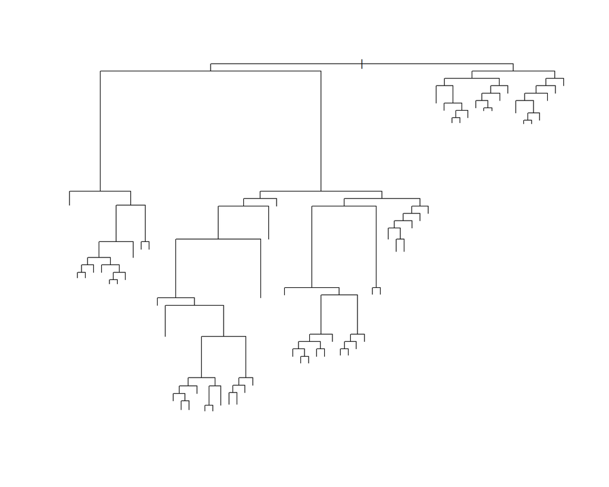

```r
plot(statusTree.p)
```

### Odczytanie ważności zmiennych

i w oparciu o te zmienne zbudowany został kolejny model **new.statusTree**.

```r
cbind(statusTree.p$variable.importance)
```

```
##                               [,1]
## level                    355.10291
## description              352.37764
## expirymonth              344.66234
## mccname                  321.27034
## countrycode              280.99181
## expiryyear               186.27626
## acquirerconnectionmethod 118.70739
## type                      69.17443
## issuer                    63.83665
## weekDay                   63.58863
## listtype                  41.20292
```

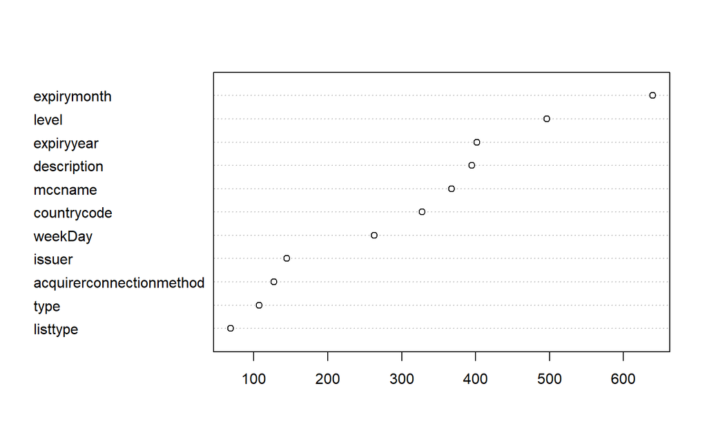

```r
dotchart(rev(statusTree$variable.importance))
```

### Zbudowanie drzewa w oparciu tylko o najważniejsze zmienne

```r
impr_uczaca <- nowa_uczaca[,c(13,9,3,5,12,10,4)]
new.statusTree <- rpart(formula = status ~ .,
                    data=impr_uczaca,
                    cp = 0, xval = 10)
```

### Wykres nowego drzewa

Nowe drzewo, stworzone tylko czy użyciu ważnych zmiennych nadal jest trudne w interpretacji, lecz zmniejszyło się w stosunku do drzewa z większą ilością zmiennych.

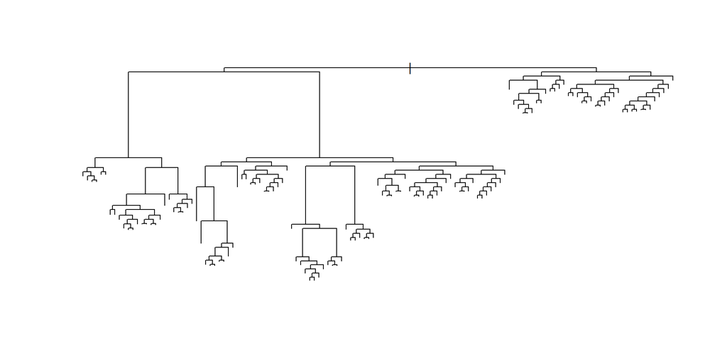

```r
plot(new.statusTree)
```

### Obliczanie błędów na bazie sprawdzania krzyżowego

Analogicznie jak w przypadku pierwszego drzewa, obliczono błędy na bazie sprawdzania krzyżowego i na tej podstawie powstało kolejne zredukowane drzewo.

```r
bledy2 <- printcp(new.statusTree) # sekwencja drzew do optymalnego przycinania
```

```
##
## Classification tree:
## rpart(formula = status ~ ., data = impr_uczaca, cp = 0, xval = 10)
##
## Variables actually used in tree construction:
## [1] acquirerconnectionmethod countrycode              description
## [4] expirymonth              level                    mccname
##
## Root node error: 3821/19031 = 0.20078
##
## n= 19031
##
##            CP nsplit rel error  xerror     xstd
## 1  2.2769e-02      0   1.00000 1.00000 0.014463
## 2  1.0294e-02      2   0.95446 0.96284 0.014257
```

[output cut: 29 more lines]

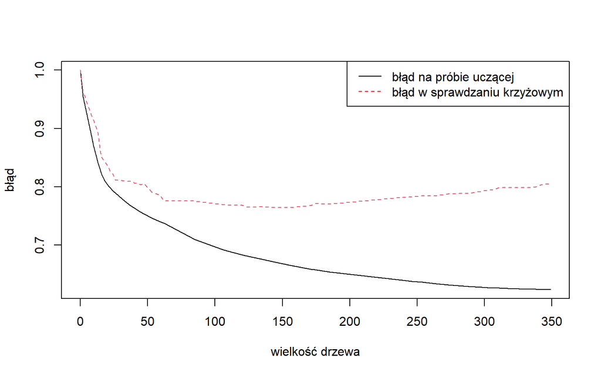

```r
matplot(x = bledy[, "nsplit"],
        y = bledy[, c("rel error",  # błąd na próbie uczącej (w stosunku do błędu dla korzenia)
                      "xerror")],  # błąd w sprawdzaniu krzyżowym
        type = "l",
        xlab = "wielkość drzewa",
        ylab = "błąd")
legend(x = "topright", legend = c("błąd na próbie uczącej",
                                  "błąd w sprawdzaniu krzyżowym"),
       col = c("black", "red"),
       lty = 1:2)
```

```r
new.statusTree$cptable
```

```
##              CP nsplit rel error    xerror       xstd
## 1  0.0227689087      0 1.0000000 1.0000000 0.01446256
## 2  0.0102939894      2 0.9544622 0.9628370 0.01425737
## 3  0.0096833290      5 0.9235802 0.9390212 0.01412161
## 4  0.0095524732      9 0.8827532 0.9309081 0.01407458
## 5  0.0074587804     11 0.8636483 0.8961005 0.01386816
## 6  0.0060193667     13 0.8487307 0.8746401 0.01373704
## 7  0.0028788275     14 0.8427113 0.8571055 0.01362764
## 8  0.0026171159     15 0.8398325 0.8547501 0.01361279
## 9  0.0023554043     16 0.8372154 0.8521329 0.01359625
## 10 0.0020936928     18 0.8325046 0.8487307 0.01357467
## 11 0.0019192184     19 0.8304109 0.8455902 0.01355468
## 12 0.0018319812     25 0.8188956 0.8458519 0.01355635
## 13 0.0014830324     27 0.8152316 0.8424496 0.01353462
## 14 0.0013085580     30 0.8107825 0.8385239 0.01350945
```

[output cut: 17 more lines]

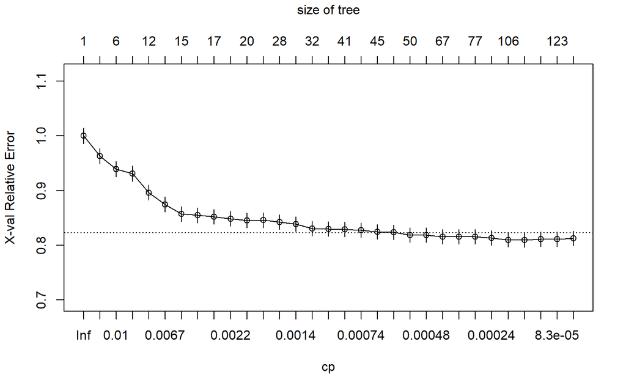

```r
plotcp(new.statusTree)
```

### Ustalanie optymalnego numeru drzewa z ograniczoną liczbą zmiennych

Przycinanie drzewa wskazało na drzewo nr. 21 z 49 punktami podziału.

```r
bledy2 <- new.statusTree$cptable
tmp12 <- which.min(bledy2[, "xerror"])
tmp22 <- sum(bledy2[tmp12, c("xerror", "xstd")])
optymalny2 <- which(bledy2[, "xerror"] < tmp22)[1]

new.statusTree.prune <- prune(new.statusTree, cp = bledy2[optymalny2, "CP"])
new.statusTree.prune$cptable
```

```
##              CP nsplit rel error    xerror       xstd
## 1  0.0227689087      0 1.0000000 1.0000000 0.01446256
## 2  0.0102939894      2 0.9544622 0.9628370 0.01425737
## 3  0.0096833290      5 0.9235802 0.9390212 0.01412161
## 4  0.0095524732      9 0.8827532 0.9309081 0.01407458
## 5  0.0074587804     11 0.8636483 0.8961005 0.01386816
## 6  0.0060193667     13 0.8487307 0.8746401 0.01373704
## 7  0.0028788275     14 0.8427113 0.8571055 0.01362764
## 8  0.0026171159     15 0.8398325 0.8547501 0.01361279
## 9  0.0023554043     16 0.8372154 0.8521329 0.01359625
## 10 0.0020936928     18 0.8325046 0.8487307 0.01357467
## 11 0.0019192184     19 0.8304109 0.8455902 0.01355468
## 12 0.0018319812     25 0.8188956 0.8458519 0.01355635
## 13 0.0014830324     27 0.8152316 0.8424496 0.01353462
## 14 0.0013085580     30 0.8107825 0.8385239 0.01350945
## 15 0.0011777022     31 0.8094740 0.8306726 0.01345879
## 16 0.0009159906     33 0.8071186 0.8298875 0.01345370
## 17 0.0007851348     40 0.7987438 0.8288406 0.01344691
## 18 0.0006978976     41 0.7979586 0.8275321 0.01343841
## 19 0.0006542790     44 0.7958650 0.8246532 0.01341966
## 20 0.0006106604     46 0.7945564 0.8241298 0.01341625
## 21 0.0005234232     49 0.7927244 0.8183722 0.01337856
```

### Wykres drzewa dla optymalnego parametru cp z ograniczoną liczbą zmiennych

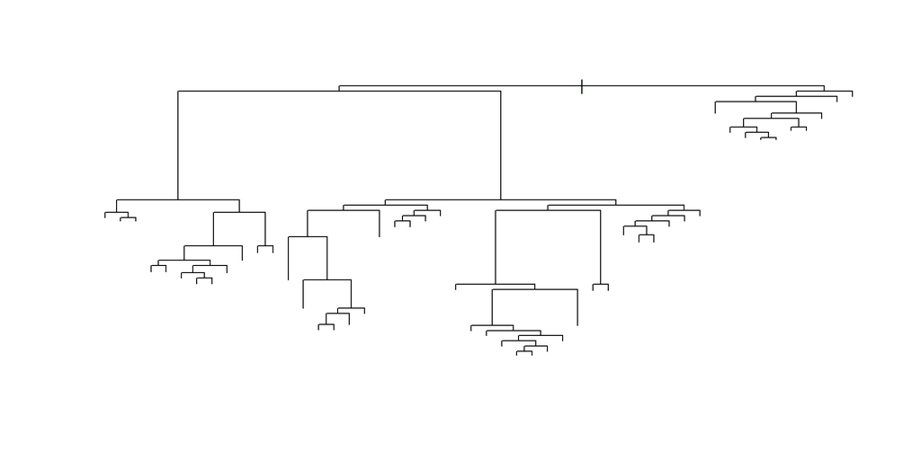

```r
plot(new.statusTree.prune)
```

### Wykonanie odpowiednich predykcji

```r
pred.prune.stat.tree.train <- predict(object = new.statusTree.prune,
                             newdata = nowa_uczaca)[,2]

pred.prune.stat.tree.walid <- predict(object = new.statusTree.prune,
                     newdata = proba_walidacyjna)[,2]

trainOcen <- miaryDokladnosci(pred.prune.stat.tree.train,
                              nowa_uczaca$status == "success",
                              name = "drzewo na podstawie próbie uczącej - ważne zmienne")

walidOcen <- miaryDokladnosci(pred.prune.stat.tree.walid,
                              proba_walidacyjna$status == "success",
                              name = "drzewo na podstawie próby walidacyjnej - ważne zmienne")

predykcjaStatTreeTrain.all <- predict(object = statusTree.p,
                                  newdata = nowa_uczaca)[,2]

predykcjaStatTreeWalid.all <- predict(object = statusTree.p,
                                  newdata = proba_walidacyjna)[,2]

trainOcen.all <- miaryDokladnosci(predykcjaStatTreeTrain.all,
                              nowa_uczaca$status == "success",
                              name = "drzewo na podstawie próbie uczącej - wszystkie zmienne")

walidOcen.all <- miaryDokladnosci(predykcjaStatTreeWalid.all,
                              proba_walidacyjna$status == "success",
                              name = "drzewo na podstawie próby walidacyjnej - wszystkie zmienne")

perftable <- rbind(trainOcen.all, walidOcen.all, trainOcen, walidOcen)
pandoc.table(perftable, justify = perf_justify)
```

```
##
##
## model                                                          accuracy       f1
## ------------------------------------------------------------ ---------- --------
## drzewo na podstawie próbie uczącej - wszystkie zmienne           0.8519   0.9684
## drzewo na podstawie próby walidacyjnej - wszystkie zmienne       0.8470   0.9619
## drzewo na podstawie próbie uczącej - ważne zmienne               0.8408   0.9648
## drzewo na podstawie próby walidacyjnej - ważne zmienne           0.8355   0.9560
##
## Table: Table continues below
##
##
##
##   dev.norm
## ----------
##     0.7951
##     0.8159
##     0.8371
##     0.8438
```

### Błędy klasyfikacji na próbie walidacyjnej

Błąd klasyfikacji dla modelu ze wszystkimi zmiennymi okazał się nieco niższy niż dla modelu z wybranymi zmiennymi.

```r
err.imp.var.class <- sum(predict(object = new.statusTree.prune,
            newdata = proba_walidacyjna,
            type = "class") != proba_walidacyjna$status) / nrow(proba_walidacyjna)

err.all.var.class <- sum(predict(object = statusTree.p,
            newdata = proba_walidacyjna,
            type = "class") != proba_walidacyjna$status) / nrow(proba_walidacyjna)

data.frame("Błąd klasyfikacji dla wszystkich zmiennych" = err.all.var.class,
           "Błąd klasyfikacji dla wybranych zmiennych" = err.imp.var.class)
```

```
##   Błąd.klasyfikacji.dla.wszystkich.zmiennych
## 1                                  0.1530072
##   Błąd.klasyfikacji.dla.wybranych.zmiennych
## 1                                 0.1645372
```

### Błędy resubstytucji na próbie uczącej

Podobnie jest w przypadku błędu resubstytucji, który w modelu uwzględniającym wszystkie zmienne okazał się mniejszy niż w modelu dla wybranych zmiennych.

```r
err.res.imp.var <- mean(predict(object = new.statusTree.prune,
                     newdata = impr_uczaca, type = 'class') != impr_uczaca$status)

err.res.all.var <- mean(predict(object = statusTree.p,
             newdata = nowa_uczaca, type = 'class') != nowa_uczaca$status)

data.frame("Błąd resubstytucji dla wszystkich zmiennych" = err.res.all.var,
           "Błąd resubstytucji dla wybranych zmiennych" = err.res.imp.var)
```

```
##   Błąd.resubstytucji.dla.wszystkich.zmiennych
## 1                                   0.1480742
##   Błąd.resubstytucji.dla.wybranych.zmiennych
## 1                                  0.1591614
```

### Macierze błędnych klasyfikacji

#### Próba walidacyjna - wybrane zmienne

```r
tabKlasWalidImp <- table(rzeczywiste = proba_walidacyjna$status,
               prognozowane = predict(object = new.statusTree.prune,
                                      newdata = proba_walidacyjna,
                                      type = "class"))
tabKlasWalidImp
```

```
##            prognozowane
## rzeczywiste fail success
##     fail     414     828
##     success  228    4948
```

#### Próba ucząca - wybrane zmienne

```r
tabKlasTrainImp <- table(rzeczywiste = nowa_uczaca$status,
                      prognozowane = predict(object = new.statusTree.prune,
                                             newdata = nowa_uczaca,
                                             type = "class"))
tabKlasTrainImp
```

```
##            prognozowane
## rzeczywiste  fail success
##     fail     1327    2494
##     success   535   14675
```

#### Próba walidacyjna - wszystkie zmienne

```r
tabKlasWalidAll <- table(rzeczywiste = proba_walidacyjna$status,
                      prognozowane = predict(object = statusTree.p,
                                             newdata = proba_walidacyjna,
                                             type = "class"))
tabKlasWalidAll
```

```
##            prognozowane
## rzeczywiste fail success
##     fail     457     785
##     success  197    4979
```

#### Próba ucząca - wszystkie

```r
tabKlasTrainAll <- table(rzeczywiste = nowa_uczaca$status,
                      prognozowane = predict(object = statusTree.p,
                                             newdata = nowa_uczaca,
                                             type = "class"))
tabKlasTrainAll
```

```
##            prognozowane
## rzeczywiste  fail success
##     fail     1484    2337
##     success   481   14729
```

### Budowa modelu metodą BAGGING

### Wykres pojedynczego drzewa stworzonego metodą bagging

Poniżej przedstawiono przykładowe drzewo klasyfikacyjne stworzone z wykorzystaniem metody bagging.

W pierwszym podziale zbioru 52% jednostek zostało zakwalifikowanych jako jednostki z 0.72 prawdopodobieństwem sukcesu, pozostałe 48% skategoryzowane były jako jednostki z 0.89 prawdopodobieństwem sukcesu. W kolejnej iteracji 48% jednostek zostało zaklasyfikowanych jako jednostki z 0.75 prawdopodobieństwa sukcesu, natomiast 4% jednostek zostało zakwalifikowanych jako jednostki z 0.37 prawdopodobieństwem na nieudaną transakcję itd..

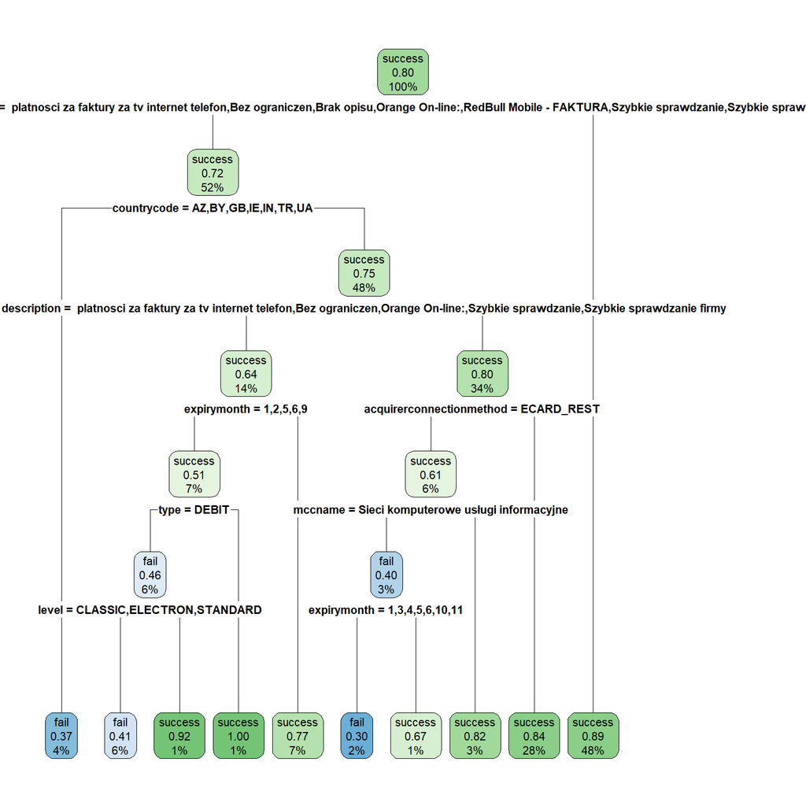

```r
bagg.status.tree.train <- bagging(status ~ . - id - createtime, data = nowa_uczaca, mfinal = 30, maxdepth=5)
bagg.status.tree.walid <- bagging(status ~ . - id - createtime, data = proba_walidacyjna, mfinal = 30, maxdepth=5)

rpart.plot(bagg.status.tree.train$trees[[2]], roundint = FALSE)
```

### Wykres błędów na zbiorze walidacyjnym oraz uczącym

Na zbiorze walidacyjnym błąd jest nieco niższy, choć wraz ze wzrostem iteracji błąd “się wypłaszcza”.

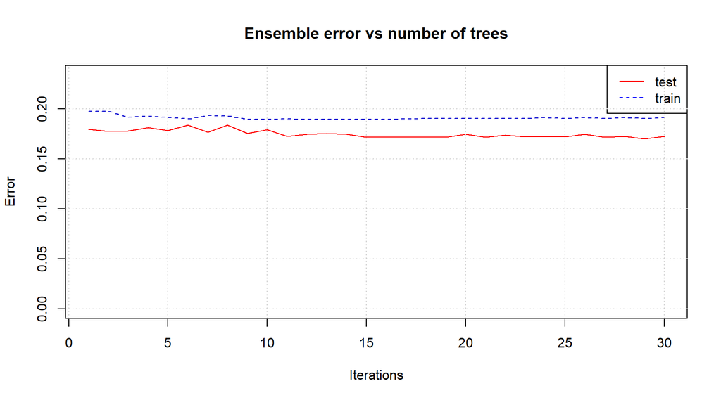

```r
plot.errorevol(
  errorevol(object = bagg.status.tree.train, newdata = proba_walidacyjna),
  errorevol(object = bagg.status.tree.walid, newdata = nowa_uczaca))

grid()
```

### Wykres ważności zmiennych

W modelu oszacowanym za pomocą metody bagging najistotniejszymi zmiennymi okazały się:

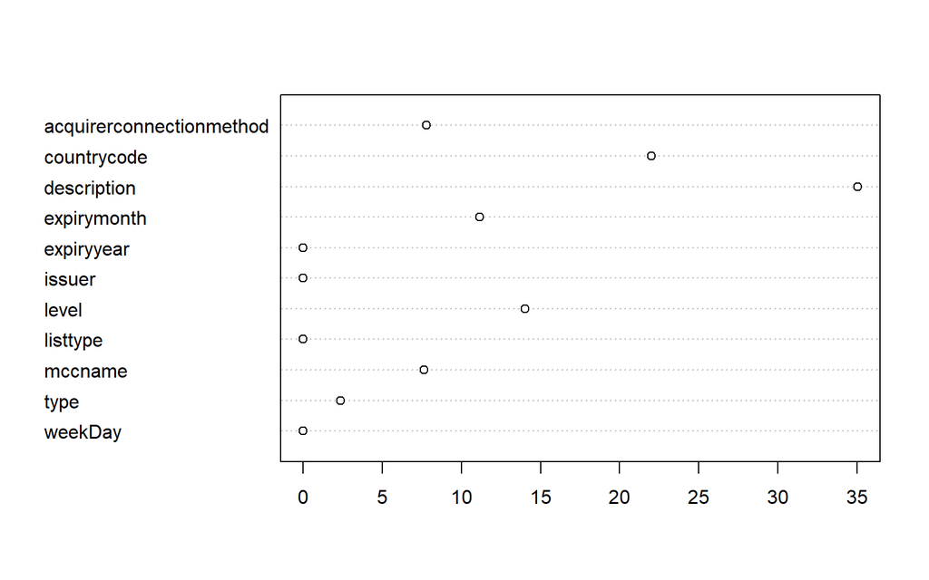

```r
dotchart(rev(bagg.status.tree.train$importance))
```

### Predykcja za pomocą metody bagging, macierz błędnych klasyfikacji oraz błąd klasyfikacji

Poniżej przedstawiono macierz błędnych klasyfikacji oraz błąd klasyfikacji dla modelu bagging z parametrem mfinal = 30

```r
bagg.status.tree.pred <- predict.bagging(bagg.status.tree.train, newdata = proba_walidacyjna)
bagg.status.tree.pred$confusion
```

```
##                Observed Class
## Predicted Class fail success
##         fail     279     144
##         success  963    5032
```

```r
bagg.status.tree.pred$confusion <- as.table(bagg.status.tree.pred$confusion)
err.bagg.class <- bagg.status.tree.pred$error
err.bagg.class
```

```
## [1] 0.1724836
```

### Zbudowanie modelu metodą bagging na podstawie ustalonej optymalnej liczby modeli bazowych

```r
mfinal.min <- which.min(errorevol(object = bagg.status.tree.walid, newdata = proba_walidacyjna)$error)
bagg.status.tree.train <- bagging(status ~ . - id - createtime, data = nowa_uczaca, mfinal = mfinal.min, maxdepth=5)
```

### Macierz błędnych klasyfikacji oraz błąd klasyfikacji dla nowego modelu

Zaprezentowane poniżej wyniki dotyczą modelu bagging stworzonego na podstawie ustalonej optymalnej liczby modeli bazowych.

```r
min.bagg.status.tree.pred <- predict.bagging(bagg.status.tree.train, newdata = proba_walidacyjna)
min.bagg.status.tree.pred$confusion
```

```
##                Observed Class
## Predicted Class fail success
##         fail     333     163
##         success  909    5013
```

```r
min.bagg.status.tree.pred$confusion <- as.table(min.bagg.status.tree.pred$confusion)
min.bagg.status.tree.pred$error
```

```
## [1] 0.1670302
```

### Błąd klasyfikacji i macierz pomyłek dla lepszego modelu bagging

W celu wybrania lepszego modelu zbudowanego za pomocą metody bagging napisano funkcję, która porównuje obydwa błędy i następnie zapisuje do ostatecznych wyników ten mniejszy. Funkcja powiązana jest z drugą funkcją, która wybiera macierz błędnych klasyfikacji dla modelu z mniejszym błędem. Zaprezentowany został również wynik działania tych funkcji.

```r
czyMniejszy <- function(x,y){
  if (x < y){
    final.bagg.error <- x}

  else {
    final.bagg.error <- y }

  final.bagg.error
}

final.bagg.error.score <- czyMniejszy(min.bagg.status.tree.pred$error, err.bagg.class)


czyMniejszy2 <- function(x,y){
  if (min.bagg.status.tree.pred$error < err.bagg.class){
    final.bagg.conf <- x}

  else {
    final.bagg.conf <- y }

  final.bagg.conf <- as.table(final.bagg.conf)
  final.bagg.conf
}

final.bagg.conf.score <- czyMniejszy2(min.bagg.status.tree.pred$confusion, bagg.status.tree.pred$confusion)

final.bagg.error.score
```

```
## [1] 0.1670302
```

```r
final.bagg.conf.score
```

```
##                Observed Class
## Predicted Class fail success
##         fail     333     163
##         success  909    5013
```

### Zbudowanie modelu metodą boosting wraz z wykresem błędu na zbiorze uczącym i walidacyjnym

W kolejnym oszacowanym modelu, tym razem zbudowanym z wykorzystaniem metody boosting, udało się znacząco zmniejszyć różnice pomiędzy błędami na zbiorze uczącym oraz walidacyjnym.

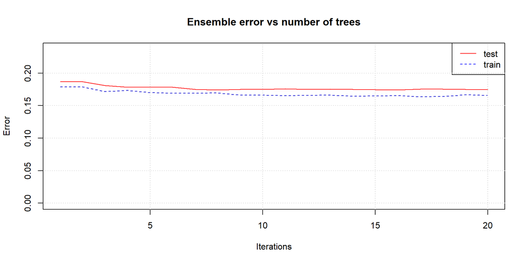

```r
boost.status.tree.train <- boosting(status ~ . - id - createtime, data = nowa_uczaca, mfinal = 20)
boost.status.tree.walid <- boosting(status ~ . - id - createtime, data = proba_walidacyjna, mfinal = 20)

plot.errorevol(
  errorevol(object = boost.status.tree.train, newdata = nowa_uczaca),
  errorevol(object = boost.status.tree.walid, newdata = proba_walidacyjna))

grid()
```

### Wykres ważności zmiennych

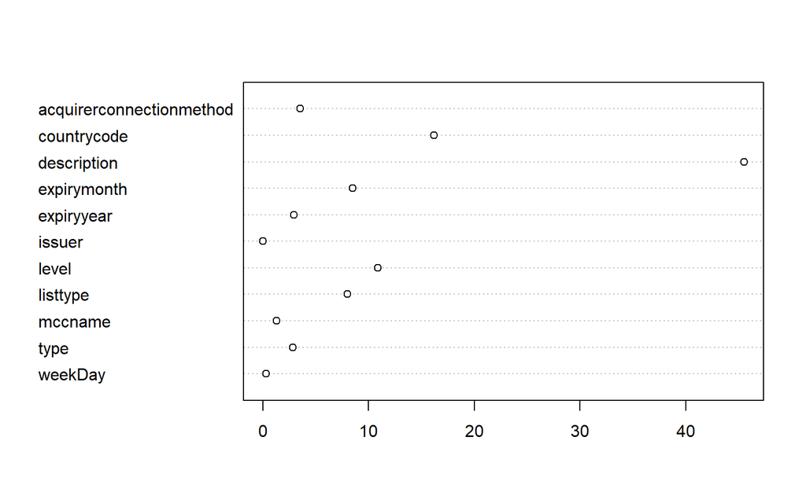

```r
dotchart(rev(boost.status.tree.train$importance))
```

### Macierz błędnych klasyfikacji i błąd klasyfikacji dla modelu Boosting

```r
boost.status.tree.pred <- predict.boosting(boost.status.tree.train, newdata = proba_walidacyjna)
boost.status.tree.pred$confusion
```

```
##                Observed Class
## Predicted Class fail success
##         fail     321     208
##         success  921    4968
```

```r
boost.status.tree.pred$confusion <- as.table(boost.status.tree.pred$confusion)
err.boost.class <- boost.status.tree.pred$error
err.boost.class
```

```
## [1] 0.1759115
```

### Budowa modelu metodą RANDOM FOREST

Kolejnym oszacowanym modelem jest model zbudowany za pomocą metody Random Forest. Oszacowany model złożony jest ze 100 drzew, natomiast sprawdzenie błędu OOB następowało co 10 drzew - przy setnym drzewie ten błąd oscyluje wokół 14%.

```r
status.fr <- randomForest(status ~. - id - createtime, data=nowa_uczaca, do.trace = 10, ntree=100, keep.forest = TRUE)
```

```
## ntree      OOB      1      2
##    10:  15.47% 54.25%  5.71%
##    20:  14.73% 55.82%  4.41%
##    30:  14.47% 55.56%  4.14%
##    40:  14.43% 55.95%  4.00%
##    50:  14.27% 55.69%  3.86%
##    60:  14.32% 56.16%  3.81%
##    70:  14.32% 56.22%  3.80%
##    80:  14.26% 56.40%  3.68%
##    90:  14.35% 56.71%  3.71%
##   100:  14.27% 56.92%  3.56%
```

```r
print(status.fr)
```

```
##
## Call:
##  randomForest(formula = status ~ . - id - createtime, data = nowa_uczaca,      do.trace = 10, ntree = 100, keep.forest = TRUE)
##                Type of random forest: classification
##                      Number of trees: 100
## No. of variables tried at each split: 3
##
##         OOB estimate of  error rate: 14.27%
## Confusion matrix:
##         fail success class.error
## fail    1646    2175   0.5692227
## success  541   14669   0.0355687
```

### Porównanie zbioru uczącego i testowego

Oba modele znacznie trafniej klasyfikują transakcje udane, co wynika z wysokiej dysproporcji w liczebnościach obu wariantów zmiennej **status**. Najprawdopodobniej pożądanym wynikiem byłby wynik odwrotny, bowiem istotniejsze wydaje się być sklasyfikowanie transakcji nieudanych i rozwiązanie potencjalnych problemów.

```r
x.test <- proba_walidacyjna[,c(-1,-2,-13)]
y.test <- proba_walidacyjna$status
status.fr2 <- randomForest(status ~. - id - createtime, data=nowa_uczaca, xtest= x.test,
                           ytest=y.test, ntree = 100)
print(status.fr2)
```

```
##
## Call:
##  randomForest(formula = status ~ . - id - createtime, data = nowa_uczaca,      xtest = x.test, ytest = y.test, ntree = 100)
##                Type of random forest: classification
##                      Number of trees: 100
## No. of variables tried at each split: 3
##
##         OOB estimate of  error rate: 14.13%
## Confusion matrix:
##         fail success class.error
## fail    1658    2163  0.56608218
## success  527   14683  0.03464826
##                 Test set error rate: 13.82%
## Confusion matrix:
##         fail success class.error
## fail     533     709  0.57085346
## success  178    4998  0.03438949
```

### Wykres ważności zmiennych

W nowym modelu oszacowanym za pomocą metody Random Forest najistotniejszymi zmiennymi okazały się:

- **expirymonth**,
- **level**,
- **description**,
- **expiryyear**,
- **weekDay**,
- **countrycode**,
- **mccname**,
- **acquirerconnectionmethod**,
- **type**,
- **issuer**,
- **listtype**,

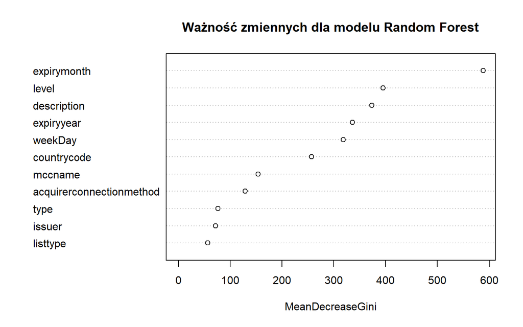

```r
varImpPlot(status.fr2,
           sort = T,
           main = "Ważność zmiennych dla modelu Random Forest")
```

### Wykres prezentujący zmianę błędu klasyfikacji na zbiorze walidacyjnym i uczących w zależności od liczby drzew

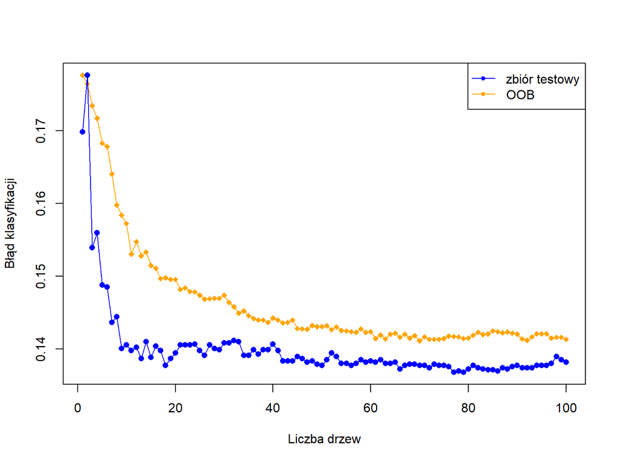

```r
bl.oob <- status.fr2$err.rate[,1]
bl.test <- status.fr2$test$err.rate[,1]
#wykres
plot(1:100, ylim=c(min(bl.test, bl.oob), max(bl.test, bl.oob)),
     xlab="Liczba drzew", ylab="Błąd klasyfikacji", type='n')
points(1:100, bl.oob, col="orange", pch=18)
points(1:100, bl.test, col="blue", pch=16)
lines(1:100, bl.oob, col="orange")
lines(1:100, bl.test, col="blue")
leg <- c("zbiór testowy", "OOB")
legend('topright', legend=leg, col=c("blue","orange"), lty=1, pch=20)
```

### Macierz błędnym klasyfikacji i błąd klasyfikacji dla zbioru uczącego

W porównaniu z wcześniej zbudowanymi modelami, w przypadku modelu oszacowanego metodą Random Forest błąd klasyfikacji znacząco się zmniejszył zarówno dla próby uczącej jak i walidacyjnej.

```r
status.fr2$confusion <- as.table(status.fr2$confusion)
err.rf.status.train <- tail(status.fr2$err.rate,1)[1]
status.fr2$confusion
```

```
##                 fail      success  class.error
## fail    1.658000e+03 2.163000e+03 5.660822e-01
## success 5.270000e+02 1.468300e+04 3.464826e-02
```

```r
err.rf.status.train
```

```
## [1] 0.1413483
```

### Macierz błędnym klasyfikacji i błąd klasyfikacji dla zbioru walidacyjnego

```r
status.tf.pred.table <- as.table(confusionMatrix(predykcje.rf.walid, proba_walidacyjna$status)$table)
err.rf.status.test <- (status.tf.pred.table[1,2] + status.tf.pred.table[2,1]) / nrow(proba_walidacyjna)
status.tf.pred.table
```

```
##           Reference
## Prediction fail success
##    fail     531     181
##    success  711    4995
```

```r
err.rf.status.test
```

```
## [1] 0.1389841
```

## **Podsumowanie wyników dla zadania 1.**

### Zestawienie błędów klasyfikacji dla badanych modeli

Najmniejszy błąd klasyfikacyjny przeważnie wychodził dla modelu **Random Forest** dla danych walidacyjnych. Niski był również dla modelu **Random Forest** dla danych uczących oraz dla **drzewa klasyfikacyjnego ze wszystkimi zmiennymi objaśniającymi**.

```r
bledy.podsumowanie <- cbind(c("drzewo klasyfikacyjne ze wszystkimi zmiennymi" = err.all.var.class,
        "drzewo klasyfikacyjne tylko z najważniejszymi zmiennymi" = err.imp.var.class,
        "bagging" = final.bagg.error.score,
        "boosting" = err.boost.class,
        "random forest OOB" = err.rf.status.train,
        "random forest test" = err.rf.status.test))


bledy.podsumowanie = data.frame(
  col1 = c("drzewo klasyfikacyjne ze wszystkimi zmiennymi", "drzewo klasyfikacyjne tylko z najważniejszymi zmiennymi",
           "bagging", "boosting","random forest train", 'random forest valid'),
  col2 = c(err.all.var.class, err.imp.var.class, final.bagg.error.score,  err.boost.class, err.rf.status.train, err.rf.status.test))

colnames(bledy.podsumowanie) <- c("Model", "Wartość błędu klasyfikacyjnego")
bledy.podsumowanie %>%
  kbl(caption = "Wartość błędów klasyfikacyjnych dla poszczególnych modeli") %>%
  kable_paper("hover", full_width = F, position = "left")
```

Wartość błędów klasyfikacyjnych dla poszczególnych modeli

| Model | Wartość błędu klasyfikacyjnego |
| --- | --- |
| drzewo klasyfikacyjne ze wszystkimi zmiennymi | 0.1530072 |
| drzewo klasyfikacyjne tylko z najważniejszymi zmiennymi | 0.1645372 |
| bagging | 0.1670302 |
| boosting | 0.1759115 |
| random forest train | 0.1413483 |
| random forest valid | 0.1389841 |

### Zestawienie najważniejszych miar dla zbudowanych modeli

Poniższe zestawienie prezentuje najważniejsze miary obliczone dla modeli klasyfikacyjnych. Zostały wykorzystane takie miary jak: precyzja, czułość, swoistość (specyficzność) oraz miara F. Największe miary precyzji w większości przypadków były dla modeli **Random Forest** i **Bagging**. Najważniejsza miara, miara F największa okazała się w większości przypadków dla modelu **Random Forest** stworzonego na próbie walidacyjnej.

```r
podsumowanieMiar <- function(miary) {
  TP <- miary["success","success"]
  TN <- miary["fail", "fail"]
  FP <- miary["fail", "success"]
  FN <- miary["success", "fail"]

  c(precyzja = TP/(TP + FP),
    czułość = TP/(TP + FN),
    specyficzność = TN/(TN + FP),
    F.miara = 2*TP / (2*TP + FP + FN))
}

miary.koncowe <- cbind(
"Drzewo klasyfikacyjne dla zbioru uczącego i wszystkich zmiennych" = podsumowanieMiar(tabKlasTrainImp),
"Drzewo klasyfikacyjne dla zbioru walidacyjnego i wszystkich zmiennych" = podsumowanieMiar(tabKlasWalidImp),
"Drzewo klasyfikacyjne dla zbioru uczącego i wybranych zmiennych" = podsumowanieMiar(tabKlasTrainAll),
"Drzewo klasyfikacyjne dla zbioru walidacyjnego i wszystkich zmiennych" = podsumowanieMiar(tabKlasWalidAll),
"Model boosting" = podsumowanieMiar(boost.status.tree.pred$confusion),
"Model bagging" = podsumowanieMiar(final.bagg.conf.score),
"Model random forest dla próby uczacej" = podsumowanieMiar(status.fr2$confusion),
"Model random forest dla próby walidacyjnej" = podsumowanieMiar(status.tf.pred.table))

vec.prec <- c(podsumowanieMiar(tabKlasTrainImp)[1], podsumowanieMiar(tabKlasWalidImp)[1], podsumowanieMiar(tabKlasTrainAll)[1],
              podsumowanieMiar(tabKlasWalidAll)[1], podsumowanieMiar(boost.status.tree.pred$confusion)[1], podsumowanieMiar(final.bagg.conf.score)[1],
              podsumowanieMiar(status.fr2$confusion)[1], podsumowanieMiar(status.tf.pred.table)[1])
vec.czul <- c(podsumowanieMiar(tabKlasTrainImp)[2], podsumowanieMiar(tabKlasWalidImp)[2], podsumowanieMiar(tabKlasTrainAll)[2],
              podsumowanieMiar(tabKlasWalidAll)[2], podsumowanieMiar(boost.status.tree.pred$confusion)[2], podsumowanieMiar(final.bagg.conf.score)[2],
              podsumowanieMiar(status.fr2$confusion)[2], podsumowanieMiar(status.tf.pred.table)[2])
vec.spec <- c(podsumowanieMiar(tabKlasTrainImp)[3], podsumowanieMiar(tabKlasWalidImp)[3], podsumowanieMiar(tabKlasTrainAll)[3],
              podsumowanieMiar(tabKlasWalidAll)[3], podsumowanieMiar(boost.status.tree.pred$confusion)[3], podsumowanieMiar(final.bagg.conf.score)[3],
              podsumowanieMiar(status.fr2$confusion)[3], podsumowanieMiar(status.tf.pred.table)[3])
vec.f <- c(podsumowanieMiar(tabKlasTrainImp)[4], podsumowanieMiar(tabKlasWalidImp)[4], podsumowanieMiar(tabKlasTrainAll)[4],
           podsumowanieMiar(tabKlasWalidAll)[4], podsumowanieMiar(boost.status.tree.pred$confusion)[4], podsumowanieMiar(final.bagg.conf.score)[4],
           podsumowanieMiar(status.fr2$confusion)[4], podsumowanieMiar(status.tf.pred.table)[4])


podsumowanie.final <- data.frame("Precyzja" = vec.prec,
                                 "Czułość" = vec.czul,
                                 "Specyficzność" = vec.spec,
                                 "Miara F" = vec.f)


rownames(podsumowanie.final) <- c("Drzewo klasyfikacyjne dla zbioru uczącego i wszystkich zmiennych",
                                    "Drzewo klasyfikacyjne dla zbioru walidacyjnego i wszystkich zmiennych",
                                    "Drzewo klasyfikacyjne dla zbioru uczącego i wybranych zmiennych",
                                    "Drzewo klasyfikacyjne dla zbioru walidacyjnego i wybranych zmiennych",
                                    "Model boosting",
                                    "Model bagging",
                                    "Model random forest dla próby uczacej",
                                    "Model random forest dla próby walidacyjnej")


podsumowanie.final %>%
  kbl(caption = "Wartość miar dla poszczególnych modeli") %>%
  kable_paper("hover", full_width = F, position = "left")
```

Wartość miar dla poszczególnych modeli

|  | Precyzja | Czułość | Specyficzność | Miara.F |
| --- | --- | --- | --- | --- |
| Drzewo klasyfikacyjne dla zbioru uczącego i wszystkich zmiennych | 0.8547382 | 0.9648258 | 0.3472913 | 0.9064517 |
| Drzewo klasyfikacyjne dla zbioru walidacyjnego i wszystkich zmiennych | 0.8566482 | 0.9559505 | 0.3333333 | 0.9035793 |
| Drzewo klasyfikacyjne dla zbioru uczącego i wybranych zmiennych | 0.8630611 | 0.9683761 | 0.3883800 | 0.9126905 |
| Drzewo klasyfikacyjne dla zbioru walidacyjnego i wybranych zmiennych | 0.8638099 | 0.9619397 | 0.3679549 | 0.9102377 |
| Model boosting | 0.9598145 | 0.8436067 | 0.6068053 | 0.8979666 |
| Model bagging | 0.9685085 | 0.8465046 | 0.6713710 | 0.9034060 |
| Model random forest dla próby uczacej | 0.8716016 | 0.9653517 | 0.4339178 | 0.9160844 |
| Model random forest dla próby walidacyjnej | 0.9650309 | 0.8753943 | 0.7457865 | 0.9180298 |

### Zapisanie wartości zmiennej “status” do próby testowej na podstawie modelu random forest

W ostatnim etapie dokonano predykcji zmiennej **status** dla próby testowej.

```r
predykcje.rf.test <- predict(status.fr, newdata = proba_testowa_final, block.size = 1)
proba_testowa_final$status <- predykcje.rf.test
table(proba_testowa_final$status)
```

```
##
##    fail success
##     495   12951
```

## **ZADANIE 2. Budowa modelu w oparciu o zmienną ilościową “amount”**

### Czynności mające na celu przygotowanie próby uczącej i testowej do zbudowania modelu.

Ze względu na wcześniejsze liczne operacje na danych, zbiór źródłowy został wgrany ponownie. Dane zostały również ponownie przetransformowane - analogicznie jak wcześniej z wyjątkiem zmiennej **status**.

```r
load("dane_zaliczenie.RData")

proba_uczaca$description <- ifelse(proba_uczaca$description == "", "Brak opisu", proba_uczaca$description)
proba_uczaca$description <- ifelse(is.na(proba_uczaca$description), "Brak opisu", proba_uczaca$description)

nowa_uczaca <- proba_uczaca %>%
  select(id, createtime, amount, description, recurringaction, acquirerconnectionmethod, expirymonth, expiryyear, issuer,
         type, level, countrycode, listtype, mccname) %>%
  filter(recurringaction == "AUTO") %>%
  mutate(acquirerconnectionmethod = factor(acquirerconnectionmethod),
         expirymonth = factor(expirymonth),
         description = factor(description),
         expiryyear = factor(expiryyear),
         issuer = factor(issuer),
         type = factor(type),
         level = factor(level),
         countrycode = factor(countrycode),
         listtype = factor(listtype),
         mccname = factor(mccname))

nowa_uczaca$recurringaction <- NULL

nowa_uczaca$weekDay <- weekdays(as.Date(nowa_uczaca$createtime))
nowa_uczaca$weekDay <- as.factor(nowa_uczaca$weekDay)

nowa_uczaca$weekDay <- factor(nowa_uczaca$weekDay, levels= c("poniedziałek", "wtorek",
                                                             "środa", "czwartek", "piątek", "sobota", "niedziela"))
```

### Podsumowanie próby uczącej

Zbiór danych jest taki sam jak wcześniej z wyłączeniem zmiennej **status**.

```r
str(nowa_uczaca)
```

```
## 'data.frame':    25451 obs. of  14 variables:
##  $ id                      : int  2783 13177 19604 25072 37463 49995 61735 15088 15135 40452 ...
##  $ createtime              : POSIXct, format: "2020-07-08 23:13:33" "2020-08-08 23:13:48" ...
##  $ amount                  : num  25 25 8 25 25 ...
##  $ description             : Factor w/ 11 levels " platnosci za faktury za tv internet telefon",..: 6 6 6 6 6 6 5 3 3 3 ...
##  $ acquirerconnectionmethod: Factor w/ 2 levels "ECARD_REST","FDP_SOAP": 2 2 2 2 2 2 2 2 2 2 ...
##  $ expirymonth             : Factor w/ 12 levels "1","2","3","4",..: 12 12 12 12 12 12 12 12 12 12 ...
##  $ expiryyear              : Factor w/ 10 levels "2020","2021",..: 1 1 1 1 1 1 1 1 1 1 ...
##  $ issuer                  : Factor w/ 3 levels "MAESTRO","MASTERCARD",..: 3 3 3 3 3 3 3 2 2 2 ...
##  $ type                    : Factor w/ 2 levels "CREDIT","DEBIT": 2 2 2 2 2 2 2 2 2 2 ...
##  $ level                   : Factor w/ 31 levels "BLACK","BUSINESS",..: 3 3 3 3 3 3 3 23 23 23 ...
##  $ countrycode             : Factor w/ 33 levels "AE","AZ","BY",..: 26 26 26 26 26 26 26 26 26 26 ...
##  $ listtype                : Factor w/ 3 levels "ECOMMERCE","MWF",..: 1 1 1 1 1 1 1 2 2 2 ...
##  $ mccname                 : Factor w/ 7 levels "NULL","Restauracja",..: 7 7 7 7 7 7 7 7 7 7 ...
##  $ weekDay                 : Factor w/ 7 levels "poniedziałek",..: 3 6 3 2 4 7 2 5 5 5 ...
```

```r
summary(nowa_uczaca)
```

```
##        id           createtime                      amount
##  Min.   :  2441   Min.   :2020-07-08 00:30:31   Min.   :   0.81
##  1st Qu.: 48222   1st Qu.:2020-11-04 07:04:29   1st Qu.:  25.00
##  Median : 86192   Median :2021-02-10 13:48:43   Median :  30.00
##  Mean   : 85270   Mean   :2021-01-30 07:48:20   Mean   :  63.42
##  3rd Qu.:123704   3rd Qu.:2021-05-03 07:17:55   3rd Qu.:  50.00
##  Max.   :162463   Max.   :2021-07-07 23:51:06   Max.   :2712.64
##
##                    description   acquirerconnectionmethod  expirymonth
##  Brak opisu              :9185   ECARD_REST: 1848         8      : 2464
##  Orange Flex:            :8338   FDP_SOAP  :23603         2      : 2456
##  Orange On-line:         :3610                            9      : 2405
##  PLAY - FAKTURA          :2566                            10     : 2290
##  Przejazd A4Go           :1386                            5      : 2134
##  RedBull Mobile - FAKTURA: 124                            1      : 2087
##  (Other)                 : 242                            (Other):11615
##    expiryyear          issuer          type            level
##  2024   :6567   MAESTRO   :   23   CREDIT: 3556   CLASSIC :9224
##  2023   :6399   MASTERCARD:11669   DEBIT :21895   STANDARD:8800
##  2022   :5198   VISA      :13759                  GOLD    :2458
##  2025   :3305                                     BUSINESS:2234
##  2021   :3211                                     ELECTRON: 930
##  2026   : 391                                     WORLD   : 543
##  (Other): 380                                     (Other) :1262
##   countrycode         listtype
##  PL     :23192   ECOMMERCE:20818
##  GB     : 1176   MWF      : 4319
##  UA     :  352   PUBLIC   :  314
##  BY     :  144
##  US     :  136
##  TR     :   77
##  (Other):  374
##                                               mccname              weekDay
##  NULL                                             :  694   poniedziałek:4494
##  Restauracja                                      :   22   wtorek      :4276
##  Sieci komputerowe usługi informacyjne            : 5885   środa       :3749
##  Sklepy kosmetyczne                               :    1   czwartek    :3591
##  Sklepy spożywcze różne                           :   83   piątek      :3715
##  Ubezpieczenia                                    :  561   sobota      :2817
##  Usługi biznesowe gdzie indziej nie sklasyfikowane:18205   niedziela   :2809
```

### Podsumowanie próby testowej

Analogicznie jest w przypadku próby testowej.

```r
str(proba_testowa_final)
```

```
## 'data.frame':    13446 obs. of  14 variables:
##  $ id                      : int  2702 13081 24953 37326 49909 61613 73671 85455 97474 112341 ...
##  $ createtime              : POSIXct, format: "2020-07-08 16:50:17" "2020-08-08 16:50:14" ...
##  $ description             : Factor w/ 11 levels " platnosci za faktury za tv internet telefon",..: 6 6 6 6 6 5 5 5 5 5 ...
##  $ acquirerconnectionmethod: Factor w/ 2 levels "ECARD_REST","FDP_SOAP": 2 2 2 2 2 2 2 2 2 2 ...
##  $ expirymonth             : Factor w/ 12 levels "1","2","3","4",..: 1 1 1 1 1 1 1 1 1 1 ...
##  $ expiryyear              : Factor w/ 10 levels "2020","2021",..: 6 6 6 6 6 6 6 6 6 6 ...
##  $ issuer                  : Factor w/ 3 levels "MAESTRO","MASTERCARD",..: 3 3 3 3 3 3 3 3 3 3 ...
##  $ type                    : Factor w/ 2 levels "CREDIT","DEBIT": 2 2 2 2 2 2 2 2 2 2 ...
##  $ level                   : Factor w/ 31 levels "BLACK","BUSINESS",..: 18 18 18 18 18 18 18 18 18 18 ...
##  $ countrycode             : Factor w/ 32 levels "AE","AZ","BY",..: 25 25 25 25 25 25 25 25 25 25 ...
##  $ listtype                : Factor w/ 3 levels "ECOMMERCE","MWF",..: 1 1 1 1 1 1 1 1 1 1 ...
##  $ mccname                 : Factor w/ 6 levels "NULL","Restauracja",..: 6 6 6 6 6 6 6 6 6 6 ...
##  $ weekDay                 : Factor w/ 7 levels "poniedziałek",..: 3 6 2 4 7 2 5 1 1 4 ...
##  $ status                  : Factor w/ 2 levels "fail","success": 2 2 2 2 2 2 2 2 2 2 ...
##  - attr(*, "na.action")= 'omit' Named int [1:38] 1991 1992 1993 1994 1995 1996 4173 4174 4175 4176 ...
##   ..- attr(*, "names")= chr [1:38] "1991" "1992" "1993" "1994" ...
```

```r
summary(proba_testowa_final)
```

```
##        id           createtime                                    description
##  Min.   :  2445   Min.   :2020-07-08 00:59:09   Brak opisu              :4108
##  1st Qu.: 51214   1st Qu.:2020-11-12 03:51:55   Orange Flex:            :3980
##  Median : 84543   Median :2021-02-06 11:13:30   Przejazd A4Go           :2655
##  Mean   : 85559   Mean   :2021-01-31 04:14:08   Orange On-line:         :1486
##  3rd Qu.:122376   3rd Qu.:2021-04-30 06:47:57   PLAY - FAKTURA          :1004
##  Max.   :162456   Max.   :2021-07-07 23:28:02   RedBull Mobile - FAKTURA: 103
##                                                 (Other)                 : 110
##  acquirerconnectionmethod  expirymonth     expiryyear          issuer
##  ECARD_REST:  772         1      :1701   2023   :3407   MAESTRO   :  12
##  FDP_SOAP  :12674         9      :1491   2024   :3029   MASTERCARD:6996
##                           10     :1380   2022   :2656   VISA      :6438
##                           3      :1199   2021   :2346
##                           7      :1164   2025   :1709
##                           4      :1097   2026   : 171
##                           (Other):5414   (Other): 128
##      type             level       countrycode         listtype
##  CREDIT: 1523   CLASSIC  :4389   PL     :12482   ECOMMERCE:11425
##  DEBIT :11923   STANDARD :3667   GB     :  513   MWF      : 1885
##                 BUSINESS :2052   UA     :   91   PUBLIC   :  136
##                 GOLD     :1151   US     :   80
##                 CORPORATE: 920   IE     :   65
##                 ELECTRON : 339   BY     :   54
##                 (Other)  : 928   (Other):  161
##                                               mccname              weekDay
##  NULL                                             :  309   poniedziałek:2366
##  Restauracja                                      :    4   wtorek      :2212
##  Sieci komputerowe usługi informacyjne            : 2712   środa       :2051
##  Sklepy spożywcze różne                           :  110   czwartek    :1913
##  Ubezpieczenia                                    :   93   piątek      :2038
##  Usługi biznesowe gdzie indziej nie sklasyfikowane:10218   sobota      :1396
##                                                            niedziela   :1470
##      status
##  fail   :  495
##  success:12951
##
##
##
##
##
```

### Zbudowanie modelu drzewa regresyjnego dla zmiennej ‘amount’

Dla zmiennej zależnej ilościowej **amount** oszacowano model, którego wykres widoczny jest poniżej.

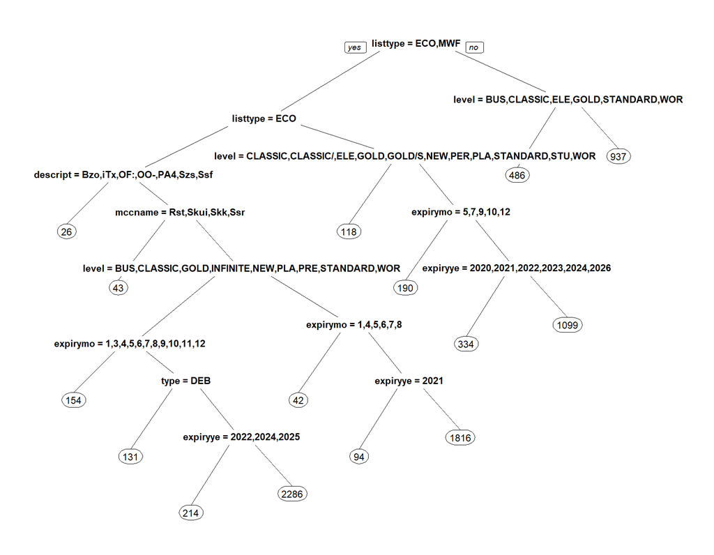

```r
drzewo.reg <- rpart(amount ~. -id - createtime, data = nowa_uczaca)
prp(drzewo.reg)
```

### Wykresy przedstawiające zmianę wartości R2 i błędu krzyżowego w zależności od podziału drzewa

Wraz ze wzrostem liczby punktów podziału, wartość R-kwadrat wzrasta, zaś wartość błędu krzyżowego maleje.

```r
rsq.rpart(drzewo.reg)
```

```
##
## Regression tree:
## rpart(formula = amount ~ . - id - createtime, data = nowa_uczaca)
##
## Variables actually used in tree construction:
## [1] description expirymonth expiryyear  level       listtype    mccname
## [7] type
##
## Root node error: 413272624/25451 = 16238
##
## n= 25451
##
##         CP nsplit rel error  xerror     xstd
## 1 0.164634      0   1.00000 1.00006 0.069903
## 2 0.080663      1   0.83537 0.83609 0.066252
## 3 0.035916      2   0.75470 0.75555 0.065976
## 4 0.034148      4   0.68287 0.68942 0.062446
## 5 0.033599      5   0.64872 0.65764 0.060101
## 6 0.029232      8   0.53634 0.60249 0.056869
## 7 0.012833     11   0.44864 0.56173 0.052168
## 8 0.012535     13   0.42298 0.53972 0.046297
## 9 0.010000     14   0.41044 0.51622 0.045217
```

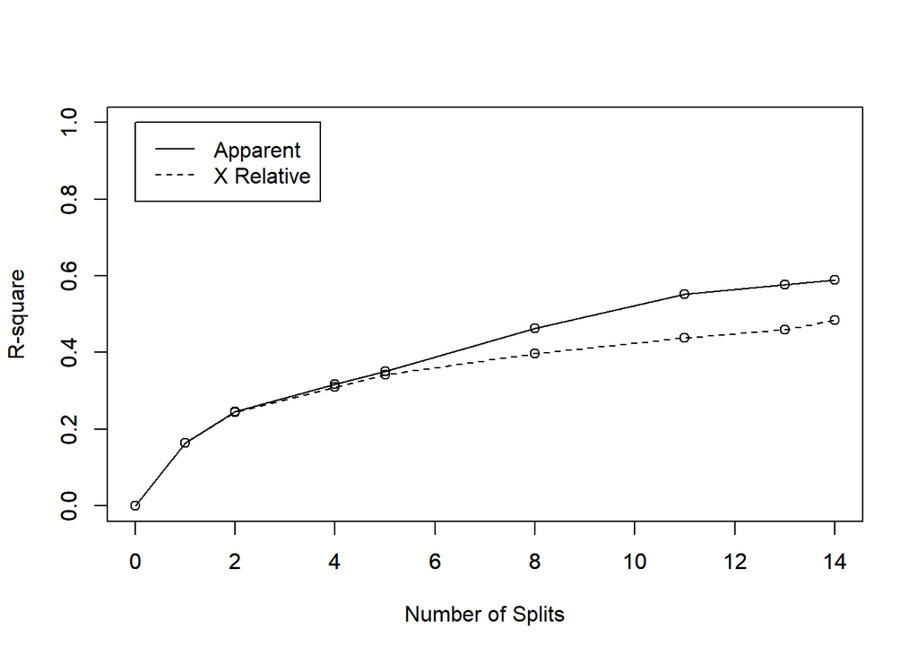

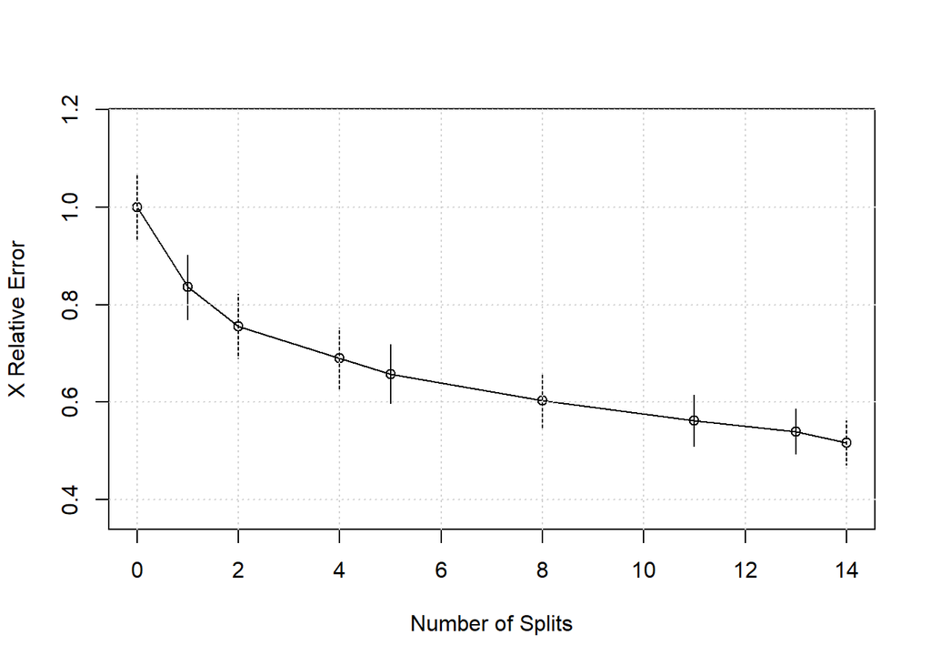

```r
grid()
```

### Sumy kwadratów reszt dla poszczególnych warunków

Jak widać poniżej, wartości sumy kwadratów reszt są stosunkowo wysokie, zatem w grupach występuje duża zmienność.

```r
y <- nowa_uczaca$amount
sum((y-mean(y))^2)
```

```
## [1] 413272624
```

```r
ss <- function (x) sum((x-mean(x))^2)
ss(y)
```

```
## [1] 413272624
```

```r
ss(y[nowa_uczaca$listtype %in% c("MWF","ECOMMERCE")])
```

```
## [1] 312087489
```

```r
ss(y[!(nowa_uczaca$listtype %in% c("MWF","ECOMMERCE"))])
```

```
## [1] 33146235
```

### Miary ważności zmiennych

W oszacowanym modelu najistotniejszymi zmiennymi okazały się:

- **listtype**,
- **expiryyear**,
- **level**,
- **mccname**,
- **description**,
- **expirymonth**,
- **type**,
- **acquirerconnectionmethod**,
- **weekDay**,
- **countrycode**,
- **issuer**.

```r
drzewo.reg$variable.importance
```

```
##                 listtype               expiryyear                    level
##                101374739                 65370210                 34263262
##                  mccname              description              expirymonth
##                 29765041                 29251927                 28322838
##                     type acquirerconnectionmethod                  weekDay
##                  6791694                  5500343                  3575889
##              countrycode                   issuer
##                  3061892                  1867472
```

### Stworzenia drzewa z parametrem cp = 0.

Oszacowane zostało maksymalne drzewo z 1804 punktami podziału.

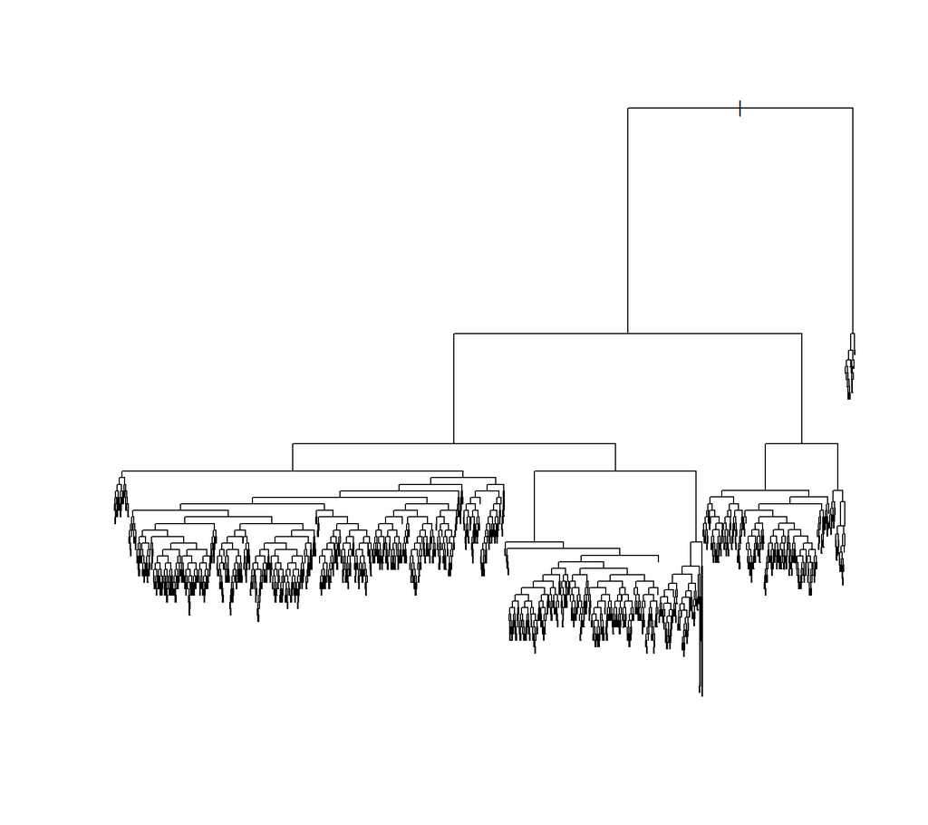

```r
drzewo.reg.big <- rpart(amount ~.-id-createtime, data = nowa_uczaca, control = rpart.control(cp=0))
plot(drzewo.reg.big)
```

```r
tail(drzewo.reg.big$cptable,15)
```

```
##                CP nsplit rel error    xerror      xstd
## 1280 1.244422e-10   1788 0.2191015 0.3579955 0.0324924
## 1281 1.228452e-10   1789 0.2191015 0.3579955 0.0324924
## 1282 1.060584e-10   1790 0.2191015 0.3579955 0.0324924
## 1283 1.008213e-10   1791 0.2191015 0.3579955 0.0324924
## 1284 8.641822e-11   1792 0.2191015 0.3579955 0.0324924
## 1285 7.702813e-11   1793 0.2191015 0.3579955 0.0324924
## 1286 4.667525e-11   1794 0.2191015 0.3579955 0.0324924
## 1287 4.478353e-11   1795 0.2191015 0.3579955 0.0324924
## 1288 4.011456e-11   1796 0.2191015 0.3579955 0.0324924
## 1289 7.090726e-13   1797 0.2191015 0.3579955 0.0324924
## 1290 2.565447e-36   1798 0.2191015 0.3579955 0.0324924
## 1291 7.329849e-37   1799 0.2191015 0.3579955 0.0324924
## 1292 3.766728e-37   1800 0.2191015 0.3579955 0.0324924
## 1293 6.108207e-38   1803 0.2191015 0.3579955 0.0324924
## 1294 0.000000e+00   1804 0.2191015 0.3579955 0.0324924
```

```r
przycinanie <- function(drzewo.reg) {
  bledy <- drzewo.reg$cptable
  tmp1 <- which.min(bledy[, "xerror"])
  tmp2 <- sum(bledy[tmp1, c("xerror", "xstd")])
  optymalny <- which(bledy[, "xerror"] < tmp2)[1]

  prune(drzewo.reg, cp = bledy[optymalny, "CP"])
}
```

### Przycięcie drzewa regresyjnego

W kolejnym etapie drzewo zostało przycięte, ograniczając liczbę punktów podziału do 53.

```r
drzewo_przyciete.reg <- przycinanie(drzewo.reg.big)
drzewo_przyciete.reg$cptable
```

```
##             CP nsplit rel error    xerror       xstd
## 1  0.164634423      0 1.0000000 1.0001057 0.06990586
## 2  0.080663070      1 0.8353656 0.8361310 0.06625813
## 3  0.035916072      2 0.7547025 0.7555288 0.06598092
## 4  0.034147908      4 0.6828704 0.7055715 0.06191850
## 5  0.033599005      5 0.6487225 0.6988058 0.06171997
## 6  0.029231560      8 0.5363370 0.6438237 0.05870356
## 7  0.012833275     11 0.4486424 0.5466454 0.05060506
## 8  0.012534790     13 0.4229758 0.5255168 0.04883269
## 9  0.007245243     14 0.4104410 0.4753375 0.04061681
## 10 0.006831831     16 0.3959505 0.4733598 0.04059971
## 11 0.006636915     17 0.3891187 0.4710346 0.04058023
## 12 0.005821776     18 0.3824818 0.4660142 0.04044368
## 13 0.004169434     20 0.3708382 0.4443863 0.03992764
## 14 0.004015202     25 0.3499911 0.4484900 0.04015174
```

[output cut: 21 more lines]

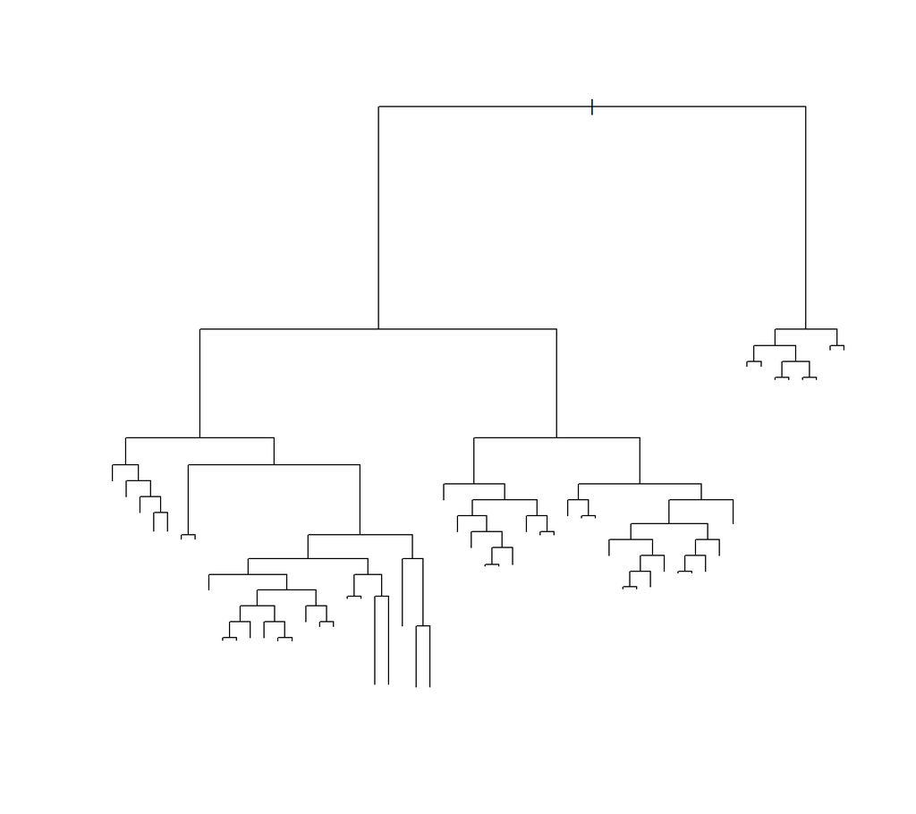

```r
plot(drzewo_przyciete.reg)
```

```r
rsq.rpart(drzewo_przyciete.reg)
```

```
##
## Regression tree:
## rpart(formula = amount ~ . - id - createtime, data = nowa_uczaca,
##     control = rpart.control(cp = 0))
##
## Variables actually used in tree construction:
##  [1] acquirerconnectionmethod description              expirymonth
##  [4] expiryyear               issuer                   level
##  [7] listtype                 mccname                  type
## [10] weekDay
##
## Root node error: 413272624/25451 = 16238
##
## n= 25451
##
```

[output cut: 36 more lines]

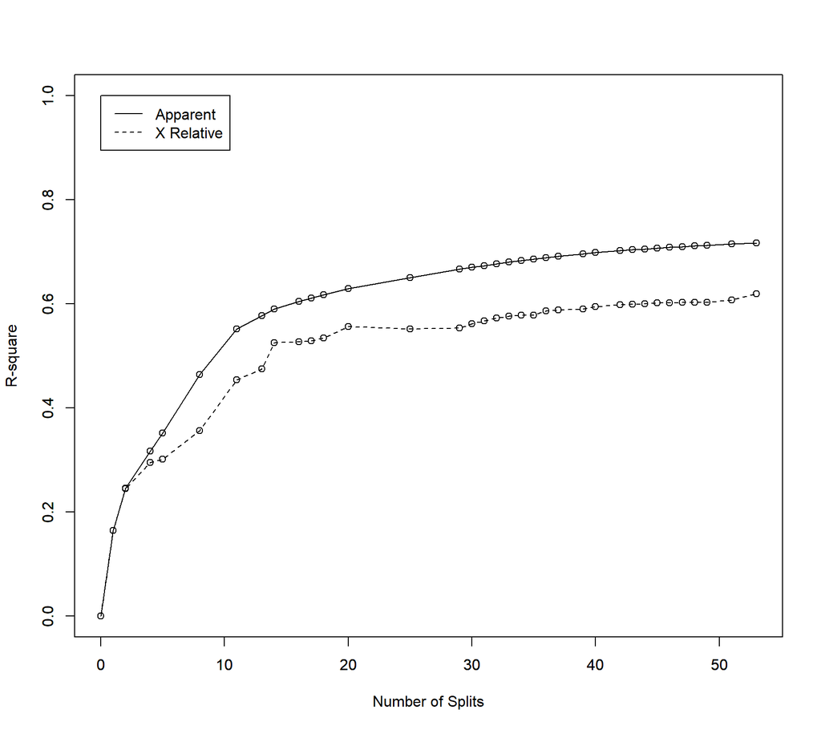

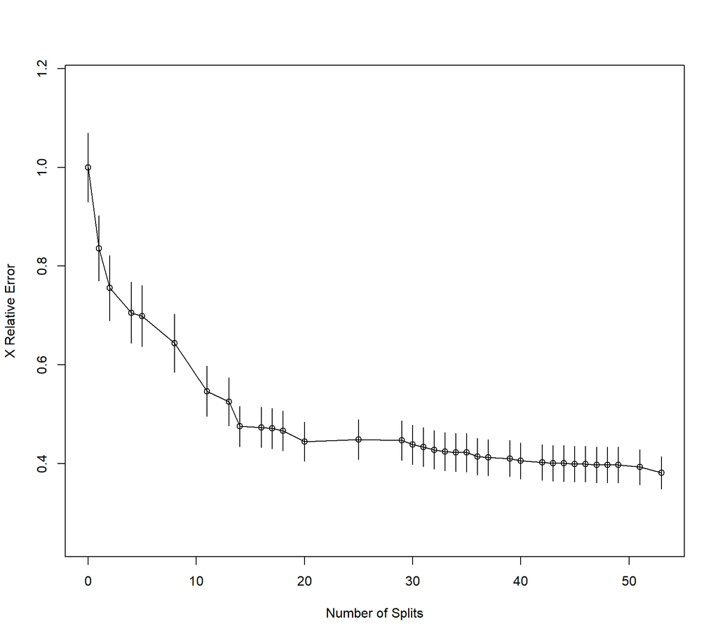

### Wybrane miary dla drzewa przyciętego

```r
sum((y - predict(drzewo_przyciete.reg))^2)
```

```
## [1] 116915656
```

```r
ss(y)
```

```
## [1] 413272624
```

```r
sum((y - predict(drzewo_przyciete.reg))^2)/ss(y)
```

```
## [1] 0.282902
```

```r
1 - sum((y - predict(drzewo_przyciete.reg))^2)/ss(y)
```

```
## [1] 0.717098
```

```r
drzewo.reg.pred <- predict(drzewo.reg, nowa_uczaca)
RMSE.reg.drzewo.first <- RMSE(pred = drzewo.reg.pred, obs = nowa_uczaca$amount)
RMSE.reg.drzewo.first
```

```
## [1] 81.6378
```

### Wizualizacja zmiennej *amount*

Obserwacje, dla których wartość zmiennej **amount** przekroczyła wartość 500 zostały zaklasyfikowane jako obserwacje nietypowe i wykluczone ze zbioru. Wobec czego **338** obserwacji zostało zakwalifikowanych jako “outliers”.

```r
summary(nowa_uczaca$amount)
```

```
##    Min. 1st Qu.  Median    Mean 3rd Qu.    Max.
##    0.81   25.00   30.00   63.42   50.00 2712.64
```

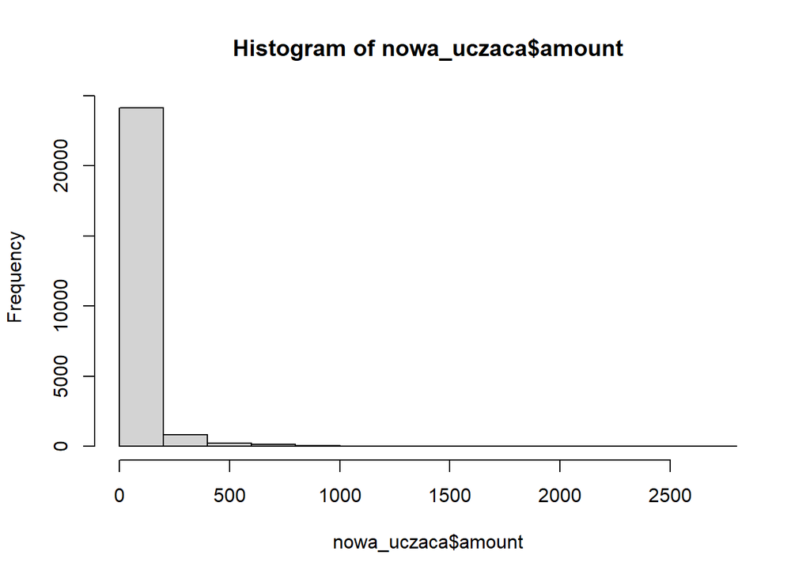

```r
hist(nowa_uczaca$amount)
```

```r
count(nowa_uczaca[nowa_uczaca$amount > 500,])
```

```
##     n
## 1 338
```

### Odrzucenie jednostek odbiegających - “outliers”

Poniżej przedstawiono histogram dla zbioru, z którego wykluczono obserwacje wyżej zaklasyfikowane jako odstające.

```r
nowa_regresja <- nowa_uczaca[nowa_uczaca$amount < 500,]
summary(nowa_regresja$amount)
```

```
##    Min. 1st Qu.  Median    Mean 3rd Qu.    Max.
##    0.81   25.00   30.00   52.21   50.00  498.04
```

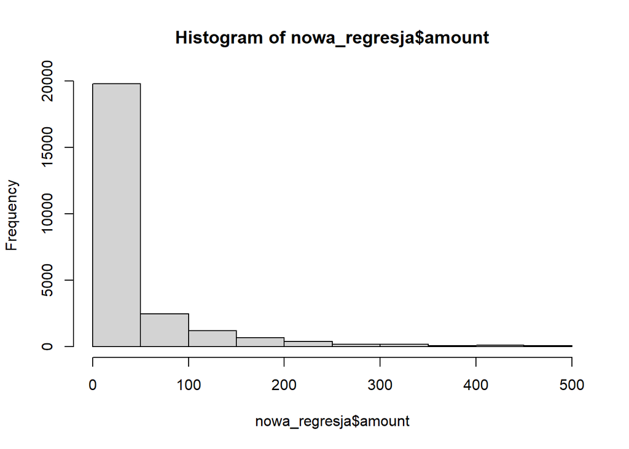

```r
hist(nowa_regresja$amount)
```